# Junior_DS_position_Assignment_A_Kochhar_upload

We will remove rare lables here because high cardinal variables causes over-fitting.

```python
### Finally, we want to explore the relationship between the categories of the different variables and product_tier

def find_frequent_labels(df, var, rare_perc):
    # finds the labels that are shared by more than a certain % of the loan purchasers
    df = df.copy()
    tmp = df.groupby(var)['product_tier'].count() / len(df)
    return tmp[tmp>rare_perc].index

for var in cat_vars:
    frequent_ls = find_frequent_labels(data_copy_clean, var, 0.01)  # 1% of the data
    data_copy_clean[var] = np.where(data_copy_clean[var].isin(frequent_ls), data_copy_clean[var], 'Rare')
```

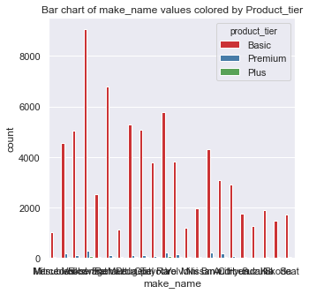

```python
# let's make histogram to visualise all categories of make_name
for var in cat_vars:
    analyse_discrete(data_copy_clean, var)
```

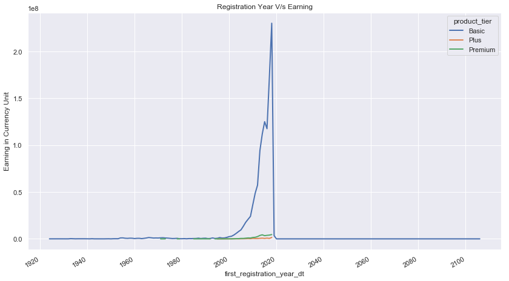

```python
#==============================================================================
# Temporal Variable: Year Wise
#==============================================================================

# let's see how the selling of articles is connected with
# registration date among different product tiers

fig = data_copy_clean.groupby(['first_registration_year_dt','product_tier'])['price'].sum().unstack().plot(
    figsize=(14, 8), linewidth=2)

fig.set_title('Registration Year V/s Earning')
fig.set_ylabel('Earning in Currency Unit')
```

The observations from above graphs is as follows:

1. The car with registration year from 2000 till 2020 are very popular in basic category.
2. In the premium category, the car from registration year 2010 were sold primarily.
3. There are cars with future registration, which is incorrect and has to be taken in account in feature engineering.

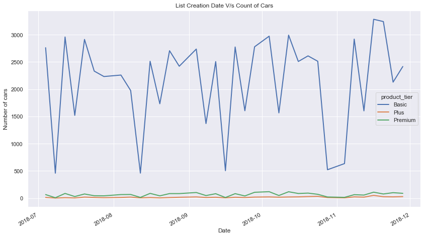

```python
#==============================================================================
# Temporal Variable: Month Wise
#==============================================================================

# let's see how the listing of articles is connected with
# number of article listed among different product tiers

fig = data_copy_clean.groupby(['created_date_dt','product_tier'])['article_id'].count().unstack().plot(
    figsize=(14, 8), linewidth=2)

fig.set_title('List Creation Date V/s Count of Cars')
fig.set_ylabel('Number of cars')
fig.set_xlabel('Date')
```

The observations from above graphs is as follows:

1. The basic tier cars were listed more than Plus and Premium tier.
2. Premium Cars were listed more than Plus tier cars.
3. There are some weeks when the Basic Car listing dropped. For this, I have to extract the week number to have a clear view.

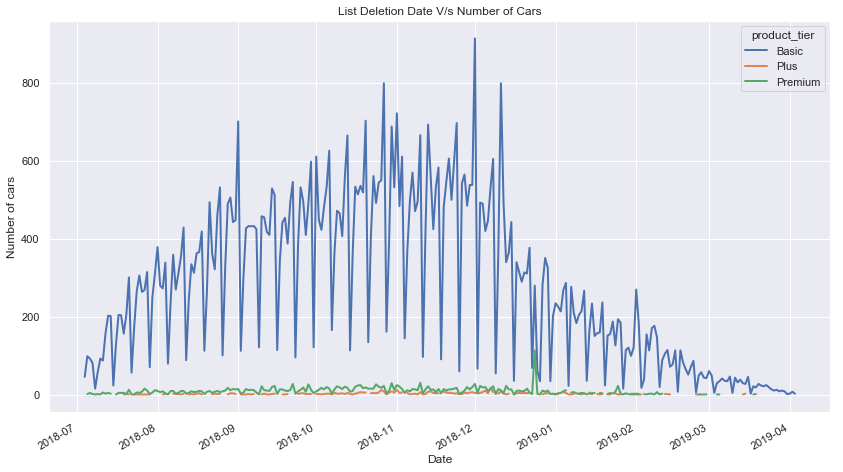

```python
#==============================================================================
# Temporal Variable: Month Wise
#==============================================================================

# let's see how the deletion of list articles is connected with
# number of article list deleted among different product tiers

fig = data_copy_clean.groupby(['deleted_date_dt','product_tier'])['article_id'].count().unstack().plot(
    figsize=(14, 8), linewidth=2)

fig.set_title('List Deletion Date V/s Number of Cars')
fig.set_ylabel('Number of cars')
fig.set_xlabel('Date')
```

The observations from above graphs is as follows:

1. Cars listing was more that Cars list deletion.
2. The basic tier cars were deleted more than Plus and Premium tier.
3. If list deletion means the selling of a car, then the car sales were high in the month of October, Novemner and December.

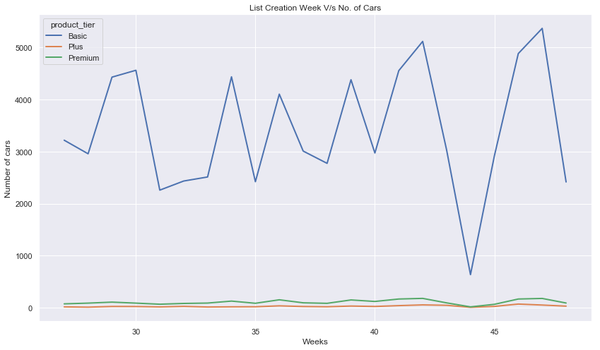

```python
#==============================================================================
# Temporal Variable: Week Wise
#==============================================================================

### Extracting week of year from date, varies from 1 to 52

data_copy_clean['created_date_dt_week'] = data_copy_clean['created_date_dt'].dt.week

data_copy_clean[['created_date_dt', 'created_date_dt_week']].head()

# let's see how the listing of articles is connected with
# number of article listed among different product tiers

fig = data_copy_clean.groupby(['created_date_dt_week','product_tier'])['article_id'].count().unstack().plot(
    figsize=(14, 8), linewidth=2)

fig.set_title('List Creation Week V/s No. of Cars')
fig.set_ylabel('Number of cars')
fig.set_xlabel('Weeks')
```

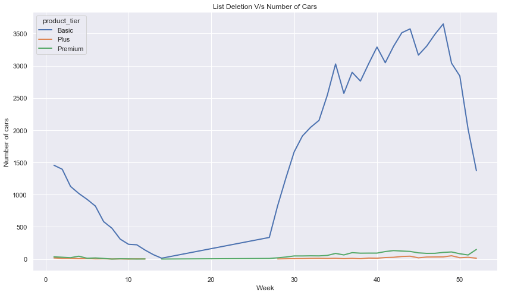

```python
#==============================================================================
# Temporal Variable: Week Wise
#==============================================================================

### Extracting week of year from date, varies from 1 to 52

data_copy_clean['deleted_date_dt_week'] = data_copy_clean['deleted_date_dt'].dt.week

data_copy_clean[['deleted_date_dt', 'deleted_date_dt_week']].head()

# let's see how the deletion of list articles is connected with
# number of article list deleted among different product tiers

fig = data_copy_clean.groupby(['deleted_date_dt_week','product_tier'])['article_id'].count().unstack().plot(
    figsize=(14, 8), linewidth=2)

fig.set_title('List Deletion V/s Number of Cars')
fig.set_ylabel('Number of cars')
fig.set_xlabel('Week')
```

From the above analysis of Date, we found that **'No. of Stock days'** obtained from 'list creation date' and 'list deletion date' is much reliable to be used for model creation.

#### ==============================================================================

#### **Feature Engineering:**

#### ==============================================================================

In the following cells, we will engineer / pre-process the variables of the Data Set. We will engineer the variables so that we tackle:

1. Missing values.
2. Zero values.
3. Negative values / Outliners.
4. Categorical variables: remove rare labels.
5. LabelEncoder: convert strings labels to numbers.
6. Feature Scaling:Standarise the values of the variables to the same range.

```python
#==============================================================================
# Import Required Packages
#==============================================================================

### to handle datasets
import pandas as pd
import numpy as np

### for plotting
import matplotlib.pyplot as plt
%matplotlib inline

### to divide train and test set
from sklearn.model_selection import train_test_split

### feature scaling
from sklearn.preprocessing import MinMaxScaler

### Label Encoding
from sklearn.preprocessing import LabelEncoder

### to visualise al the columns in the dataframe
pd.pandas.set_option('display.max_columns', None)

import seaborn as sns

### for Q-Q plots
import pylab
import scipy.stats as stats
```

```python
### Looking in data information
print(data_copy_clean.info())
```

```
<class 'pandas.core.frame.DataFrame'>
Int64Index: 78305 entries, 0 to 78320
Data columns (total 16 columns):
 #   Column                         Non-Null Count  Dtype
---  ------                         --------------  -----
 0   article_id                     78305 non-null  int64
 1   product_tier                   78305 non-null  object
 2   make_name                      78305 non-null  object
 3   price                          78305 non-null  int64
 4   first_zip_digit                78305 non-null  int64
 5   search_views                   78295 non-null  float64
 6   detail_views                   78295 non-null  float64
 7   first_registration_year_dt     78305 non-null  datetime64[ns]
 8   first_registration_year_dt_yr  78305 non-null  int64
 9   created_date_dt                78305 non-null  datetime64[ns]
 10  deleted_date_dt                78305 non-null  datetime64[ns]
 11  stock_days_dt                  78305 non-null  timedelta64[ns]
 12  ctr_calc                       78281 non-null  float64
 13  stock_days_dt_int              78305 non-null  int64
 14  created_date_dt_week           78305 non-null  int64
 15  deleted_date_dt_week           78305 non-null  int64
dtypes: datetime64[ns](3), float64(3), int64(7), object(2), timedelta64[ns](1)
memory usage: 10.2+ MB
None
```

```python
#==============================================================================
# Remove Insignificant variables
#==============================================================================

### We will remove all the insignificant variables which were found out in the previous step of Exploratory Data Analysis

master_data = data_copy_clean.drop(['article_id','first_registration_year_dt','created_date_dt','deleted_date_dt','stock_days_dt','created_date_dt_week','deleted_date_dt_week'], axis = 1)
print(master_data.info())
```

```
<class 'pandas.core.frame.DataFrame'>
Int64Index: 78305 entries, 0 to 78320
Data columns (total 9 columns):
 #   Column                         Non-Null Count  Dtype
---  ------                         --------------  -----
 0   product_tier                   78305 non-null  object
 1   make_name                      78305 non-null  object
 2   price                          78305 non-null  int64
 3   first_zip_digit                78305 non-null  int64
 4   search_views                   78295 non-null  float64
 5   detail_views                   78295 non-null  float64
 6   first_registration_year_dt_yr  78305 non-null  int64
 7   ctr_calc                       78281 non-null  float64
 8   stock_days_dt_int              78305 non-null  int64
dtypes: float64(3), int64(4), object(2)
memory usage: 6.0+ MB
None
```

```python
#==============================================================================
# Balanced v/s Imbalanced Dataset
#==============================================================================

### Checking if the dataset is balanced or imbalanced

master_data.product_tier.value_counts()
```

```
Basic      75414
Premium     2317
Plus         574
Name: product_tier, dtype: int64
```

The dataset is highly imbalanced. It will be balanced later during model creation.

```python
#==============================================================================
# Creating label for target variable
#==============================================================================

### We will create labels for target variable before hand. It will help us to make it easier going forward

###Transforming Nominal Attributes
lbl_encde = LabelEncoder()
product_tier_lbl = lbl_encde.fit_transform(master_data["product_tier"])
master_data["product_tier_lbl"] = product_tier_lbl
master_data.head()
```

|  | product_tier | make_name | price | first_zip_digit | search_views | detail_views | first_registration_year_dt_yr | ctr_calc | stock_days_dt_int | product_tier_lbl |
| --- | --- | --- | --- | --- | --- | --- | --- | --- | --- | --- |
| 0 | Basic | Mitsubishi | 16750 | 5 | 3091.0 | 123.0 | 2013 | 0.039793 | 31 | 0 |
| 1 | Basic | Mercedes-benz | 35950 | 4 | 3283.0 | 223.0 | 2015 | 0.067926 | 52 | 0 |
| 2 | Basic | Mercedes-benz | 11950 | 3 | 3247.0 | 265.0 | 1998 | 0.081614 | 51 | 0 |
| 3 | Basic | Ford | 1750 | 6 | 1856.0 | 26.0 | 2003 | 0.014009 | 101 | 0 |
| 4 | Basic | Mercedes-benz | 26500 | 3 | 490.0 | 20.0 | 2014 | 0.040816 | 11 | 0 |

```python
#==============================================================================
# Separate dataset into train and test
#==============================================================================

### Before beginning to engineer our features, it is important to separate our
### data intro training and testing set. This is to avoid over-fitting. This step
### involves randomness, therefore, we need to set the seed.

### Let's separate into train and test set
### Remember to set the seed (random_state for this sklearn function)

X_train, X_test, y_train, y_test = train_test_split(master_data, master_data.product_tier_lbl,
                                                    test_size=0.3,
                                                    random_state=0,shuffle=False) # we are setting the seed here
X_train.shape, X_test.shape
```

```
((54813, 10), (23492, 10))
```

```python
#==============================================================================
# Handling Outliners: Checking the outliner and Capping them
#==============================================================================

### function to create histogram, Q-Q plot and boxplot

def diagnostic_plots(df, variable):
    # function takes a dataframe (df) and
    # the variable of interest as arguments

    # define figure size
    plt.figure(figsize=(16, 4))

    # histogram
    plt.subplot(1, 3, 1)
    sns.distplot(df[variable], bins=30)
    plt.title('Histogram')

    # Q-Q plot
    plt.subplot(1, 3, 2)
    stats.probplot(df[variable], dist="norm", plot=pylab)
    #plt.ylabel('price')

    # boxplot
    plt.subplot(1, 3, 3)
    sns.boxplot(y=df[variable])
    plt.title('Boxplot')

    plt.show()
```

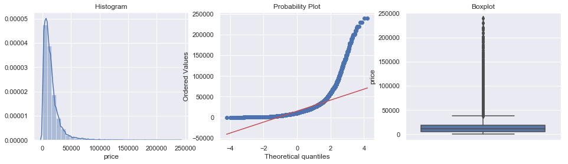

```python
#==============================================================================
#==============================================================================

### Checking the distribution of price variable in the dataset

diagnostic_plots(X_train,'price')

#==============================================================================
#==============================================================================
```

'price' is not normally distributed, it is skewed with a tail to the right. According to the boxplot, there are some outliers at the right end of the distribution of the variable.

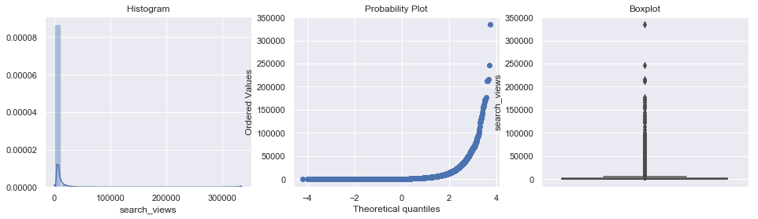

```python
#==============================================================================
#==============================================================================

### Checking the distribution of search_views variable

diagnostic_plots(X_train,'search_views')

#==============================================================================
#==============================================================================
```

'search_views' is not normally distributed, it is skewed with a tail to the right. According to the boxplot, there are some outliers at the right end of the distribution of the variable.

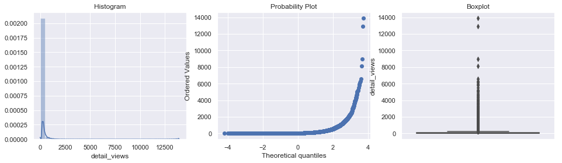

```python
#==============================================================================
#==============================================================================

### Checking the distribution of detail_views variable

diagnostic_plots(X_train,'detail_views')

#==============================================================================
#==============================================================================
```

'detail_views' is not normally distributed, it is skewed with a tail to the right. According to the boxplot, there are some outliers at the right end of the distribution of the variable.

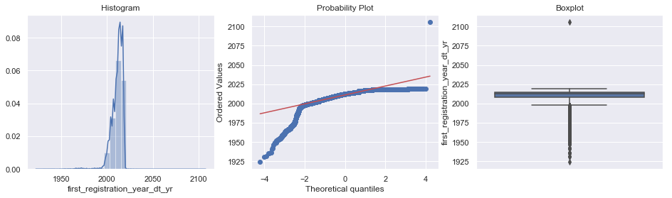

```python
#==============================================================================
#==============================================================================

### Checking the distribution of each variable

diagnostic_plots(X_train,'first_registration_year_dt_yr')

#==============================================================================
#==============================================================================
```

'first_registration_year_dt_yr' is not normally distributed, it is skewed with a tail to the left. According to the boxplot, there are some outliers at the left end of the distribution of the variable.

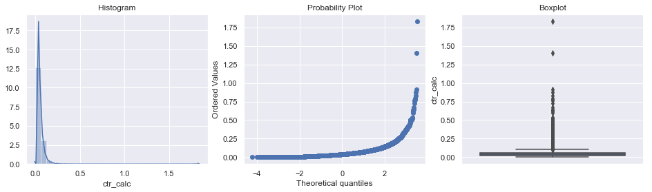

```python
#==============================================================================
#==============================================================================

### Checking the distribution of ctr_calc variable

diagnostic_plots(X_train,'ctr_calc')

#==============================================================================
#==============================================================================
```

'ctr_calc' is not normally distributed, it is skewed with a tail to the right. According to the boxplot, there are some outliers at the right end of the distribution of the variable.

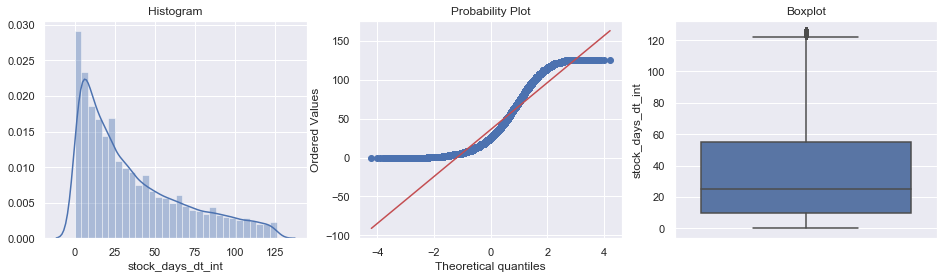

```python
#==============================================================================
#==============================================================================

### Checking the distribution of stock_days_dt_int variable

diagnostic_plots(X_train,'stock_days_dt_int')

#==============================================================================
#==============================================================================
```

```python
#==============================================================================
# Capping: Find the upper and lower boundaries of each of these variable
#==============================================================================

### function to find upper and lower boundaries for skewed distributed variables

def find_skewed_boundaries(df, variable, distance):

    # Let's calculate the boundaries outside which sit the outliers
    # for skewed distributions

    # distance passed as an argument, gives us the option to
    # estimate 1.5 times or 3 times the IQR to calculate
    # the boundaries.

    IQR = df[variable].quantile(0.75) - df[variable].quantile(0.25)

    lower_boundary = df[variable].quantile(0.25) - (IQR * distance)
    upper_boundary = df[variable].quantile(0.75) + (IQR * distance)

    return upper_boundary, lower_boundary
```

```python
#==============================================================================
#==============================================================================

### Finding the boundaries of price variable in the dataset

# looking for outliers,
# using the interquantile proximity rule
# IQR * 1.5, the standard metric

upper_boundary, lower_boundary = find_skewed_boundaries(X_train, 'price', 1.5)
upper_boundary, lower_boundary
```

```
(38500.0, -13900.0)
```

```python
### Capping the 'price' variable with boundary value

### lets look at the number and percentage of outliers for 'price'

print('total articles: {}'.format(len(X_train)))
print()
print('articles with price bigger than 38500: {}'.format(
    len(X_train[X_train['price'] > upper_boundary])))
print()
print('% articles with price bigger than 38500: {}'.format(
    len(X_train[X_train['price'] > upper_boundary])/len(X_train)))
```

```
total articles: 54813

articles with price bigger than 38500: 3182

% articles with price bigger than 38500: 0.058051921989309106
```

The upper boundary shows a value of ~38500. The lower boundary is negative, however the variable price does not take negative values. So to calculate the outliers for price we will only use the upper boundary. This coincides with what we observed in the boxplot earlier in the notebook. Outliers sit only at the right tail of price's distribution.

We observe 3182 articles, 5.8 % of the dataset, with extremely high values for price.

```python
### Now let's replace the outliers by the maximum and minimum limit

X_train['price']= np.where(X_train['price'] > upper_boundary, upper_boundary,
                       np.where(X_train['price'] < 0, 0,X_train['price']))

X_test['price']= np.where(X_test['price'] > upper_boundary, upper_boundary,
                       np.where(X_test['price'] < 0, 0,X_test['price']))

#==============================================================================
#==============================================================================
```

```python
#==============================================================================
#==============================================================================

### Finding the boundaries of search_views variable in the dataset

# looking for outliers,
# using the interquantile proximity rule
# IQR * 1.5, the standard metric

upper_boundary, lower_boundary = find_skewed_boundaries(X_train, 'search_views', 1.5)
upper_boundary, lower_boundary
```

```
(5000.0, -2408.0)
```

```python
### lets look at the number and percentage of outliers
### for 'search_views'

print('total articles: {}'.format(len(X_train)))
print()
print('articles with price bigger than 5000: {}'.format(
    len(X_train[X_train['search_views'] > upper_boundary])))
print()
print('% articles with price bigger than 5000: {}'.format(
    len(X_train[X_train['search_views'] > upper_boundary])/len(X_train)))
```

```
total articles: 54813

articles with price bigger than 5000: 5237

% articles with price bigger than 5000: 0.09554302811376864
```

The upper boundary shows a value of ~5000. The lower boundary is negative, however the variable search_views does not take negative values. So to calculate the outliers for search_views we only use the upper boundary. This coincides with what we observed in the boxplot earlier in the notebook. Outliers sit only at the right tail of price's distribution.

We observe 5237 articles, 9.5 % of the dataset, with extremely high values for search_view.

```python
### Now let's replace the outliers by the maximum and minimum limit

X_train['search_views']= np.where(X_train['search_views'] > upper_boundary, upper_boundary,
                       np.where(X_train['search_views'] < 0, 0 ,X_train['search_views']))

X_test['search_views']= np.where(X_test['search_views'] > upper_boundary, upper_boundary,
                       np.where(X_test['search_views'] < 0, 0,X_test['search_views']))

#==============================================================================
#==============================================================================
```

```python
#==============================================================================
#==============================================================================

### Finding the boundaries of detail_views variable in the dataset

# looking for outliers,
# using the interquantile proximity rule
# IQR * 1.5, the standard metric

upper_boundary, lower_boundary = find_skewed_boundaries(X_train, 'detail_views', 1.5)
upper_boundary, lower_boundary
```

```
(213.0, -107.0)
```

```python
### lets look at the number and percentage of outliers
### for 'detail_views'

print('total articles: {}'.format(len(X_train)))
print()
print('articles with price bigger than 213: {}'.format(
    len(X_train[X_train['detail_views'] > upper_boundary])))
print()
print('% articles with price bigger than 213: {}'.format(
    len(X_train[X_train['detail_views'] > upper_boundary])/len(X_train)))
```

```
total articles: 54813

articles with price bigger than 213: 5373

% articles with price bigger than 213: 0.09802419134147008
```

The upper boundary shows a value of ~213. The lower boundary is negative, however the variable detail_views does not take negative values. So to calculate the outliers for search_views we only use the upper boundary. This coincides with what we observed in the boxplot earlier in the notebook. Outliers sit only at the right tail of price's distribution.

We observe 5373 articles, 9.8 % of the dataset, with extremely high values for detail_view.

```python
### Now let's replace the outliers by the maximum and minimum limit

X_train['detail_views']= np.where(X_train['detail_views'] > upper_boundary, upper_boundary,
                       np.where(X_train['detail_views'] < 0, 0 ,X_train['detail_views']))

X_test['detail_views']= np.where(X_test['detail_views'] > upper_boundary, upper_boundary,
                       np.where(X_test['detail_views'] < 0, 0,X_test['detail_views']))

#==============================================================================
#==============================================================================
```

```python
#==============================================================================
#==============================================================================

### Finding the boundaries of first_registration_year_dt_yr variable in the dataset

# looking for outliers,
# using the interquantile proximity rule
# IQR * 1.5, the standard metric

upper_boundary, lower_boundary = find_skewed_boundaries(X_train, 'first_registration_year_dt_yr', 1.5)
upper_boundary, lower_boundary
```

```
(2025.5, 1997.5)
```

```python
### lets look at the number and percentage of outliers
### for 'first_registration_year_dt_yr'

print('total articles: {}'.format(len(X_train)))
print()
print('articles with first_registration_year bigger than 2020: {}'.format(
    len(X_train[X_train['first_registration_year_dt_yr'] > 2020])))
print()
print('% articles with first_registration_year bigger than 2020: {}'.format(
    len(X_train[X_train['first_registration_year_dt_yr'] > 2020])/len(X_train)))
print()
print('articles with first_registration_year lower than 1997: {}'.format(
    len(X_train[X_train['first_registration_year_dt_yr'] < 1997])))
print()
print('% articles with first_registration_year lower than 1997: {}'.format(
    len(X_train[X_train['first_registration_year_dt_yr'] < 1997])/len(X_train)))
```

```
total articles: 54813

articles with first_registration_year bigger than 2020: 1

% articles with first_registration_year bigger than 2020: 1.8243847262510718e-05

articles with first_registration_year lower than 1997: 867

% articles with first_registration_year lower than 1997: 0.015817415576596792
```

We observe 867 articles below 1997, 1.5 % of the dataset, with extremely low values for first_registration_year_dt_yr.

```python
### Now let's replace the outliers by the maximum and minimum limit

X_train['first_registration_year_dt_yr']= np.where(X_train['first_registration_year_dt_yr'] > upper_boundary, 2020,
                       np.where(X_train['first_registration_year_dt_yr'] < lower_boundary, 1998 ,X_train['first_registration_year_dt_yr']))

X_test['first_registration_year_dt_yr']= np.where(X_test['first_registration_year_dt_yr'] > upper_boundary, 2020,
                       np.where(X_test['first_registration_year_dt_yr'] < lower_boundary, 1998 ,X_test['first_registration_year_dt_yr']))

#==============================================================================
#==============================================================================
```

```python
#==============================================================================
#==============================================================================

### Finding the boundaries of ctr_calc variable in the dataset

# looking for outliers,
# using the interquantile proximity rule
# IQR * 1.5, the standard metric

upper_boundary, lower_boundary = find_skewed_boundaries(X_train, 'ctr_calc', 1.5)
upper_boundary, lower_boundary
```

```
(0.10977958634995248, -0.026944091269654486)
```

```python
### lets look at the number and percentage of outliers
### for 'ctr_calc'

print('total articles: {}'.format(len(X_train)))
print()
print('articles with price bigger than 0.10977: {}'.format(
    len(X_train[X_train['ctr_calc'] > upper_boundary])))
print()
print('% articles with price bigger than 0.10977: {}'.format(
    len(X_train[X_train['ctr_calc'] > upper_boundary])/len(X_train)))
```

```
total articles: 54813

articles with price bigger than 0.10977: 2789

% articles with price bigger than 0.10977: 0.05088209001514239
```

The upper boundary shows a value of ~0.10977. The lower boundary is negative, however the variable ctr_calc does not take negative values. So to calculate the outliers for ctr_calc we only use the upper boundary. This coincides with what we observed in the boxplot earlier in the notebook. Outliers sit only at the right tail of price's distribution.

```python
### Now let's replace the outliers by the maximum and minimum limit

X_train['ctr_calc']= np.where(X_train['ctr_calc'] > upper_boundary, upper_boundary,
                       np.where(X_train['ctr_calc'] < 0, 0,X_train['ctr_calc']))

X_test['ctr_calc']= np.where(X_test['ctr_calc'] > upper_boundary, upper_boundary,
                       np.where(X_test['ctr_calc'] < 0, 0,X_test['ctr_calc']))

#==============================================================================
#==============================================================================
```

```python
#==============================================================================
#==============================================================================

### Finding the boundaries of stock_days_dt_int variable in the dataset

# looking for outliers,
# using the interquantile proximity rule
# IQR * 1.5, the standard metric

upper_boundary, lower_boundary = find_skewed_boundaries(X_train, 'stock_days_dt_int', 1.5)
upper_boundary, lower_boundary
```

```
(122.5, -57.5)
```

```python
# lets look at the number and percentage of outliers
# for 'stock_days_dt_int'

print('total articles: {}'.format(len(X_train)))
print()
print('articles with price bigger than 122: {}'.format(
    len(X_train[X_train['stock_days_dt_int'] > upper_boundary])))
print()
print('% articles with price bigger than 122: {}'.format(
    len(X_train[X_train['stock_days_dt_int'] > upper_boundary])/len(X_train)))
```

```
total articles: 54813

articles with price bigger than 122: 409

% articles with price bigger than 122: 0.007461733530366884
```

```python
### Now let's replace the outliers by the maximum and minimum limit

X_train['stock_days_dt_int']= np.where(X_train['stock_days_dt_int'] > upper_boundary, 122,
                       np.where(X_train['stock_days_dt_int'] < 0, 0,X_train['stock_days_dt_int']))

X_test['stock_days_dt_int']= np.where(X_test['stock_days_dt_int'] > upper_boundary, 122,
                       np.where(X_test['stock_days_dt_int'] < 0, 0,X_test['stock_days_dt_int']))

#==============================================================================
#==============================================================================
```

```python
#==============================================================================
# Missing values: Categorical Variables
#==============================================================================

### For categorical variables, we will fill missing information by adding an additional category: "missing"

# make a list of the categorical variables that contain missing values
vars_with_na = [var for var in master_data.columns if X_train[var].isnull().sum()>1 and X_train[var].dtypes=='O']

# print the variable name and the percentage of missing values
for var in vars_with_na:
    print(var, np.round(X_train[var].isnull().mean(), 6),  ' % missing values')
```

There are no missing values in categorical variable.

```python
#==============================================================================
# Missing values: Numerical Variables
#==============================================================================

### For numerical variables, we are going to add an additional variable capturing
### the missing information, and then replace the missing information in the original
### variable by the mean (avg) or mode, or most frequent value:

# make a list of the numerical variables that contain missing values
vars_with_na = [var for var in master_data.columns if X_train[var].isnull().sum()>1 and X_train[var].dtypes!='O']

# print the variable name and the percentage of missing values
for var in vars_with_na:
    print(var, np.round(X_train[var].isnull().mean(), 6),  ' % missing values')
```

```
search_views 7.3e-05  % missing values
detail_views 7.3e-05  % missing values
ctr_calc 0.000201  % missing values
```

```python
### ALl three of the variables are continuous in nature, for which we will take mean value.
### If a variable is discrete, then we will take mode value.

# list of numerical variables
num_vars = [var for var in master_data.columns if master_data[var].dtypes != 'O']

print('Number of numerical variables: ', len(num_vars))

# visualise the numerical variables
master_data[num_vars].head()
```

```
Number of numerical variables:  8
```

|  | price | first_zip_digit | search_views | detail_views | first_registration_year_dt_yr | ctr_calc | stock_days_dt_int | product_tier_lbl |
| --- | --- | --- | --- | --- | --- | --- | --- | --- |
| 0 | 16750 | 5 | 3091.0 | 123.0 | 2013 | 0.039793 | 31 | 0 |
| 1 | 35950 | 4 | 3283.0 | 223.0 | 2015 | 0.067926 | 52 | 0 |
| 2 | 11950 | 3 | 3247.0 | 265.0 | 1998 | 0.081614 | 51 | 0 |
| 3 | 1750 | 6 | 1856.0 | 26.0 | 2003 | 0.014009 | 101 | 0 |
| 4 | 26500 | 3 | 490.0 | 20.0 | 2014 | 0.040816 | 11 | 0 |

```python
### list of discrete variables
discrete_vars = [var for var in num_vars if len(master_data[var].unique())<20]

print('Number of discrete variables: ', len(discrete_vars))

# let's visualise the discrete variables
master_data[discrete_vars].head()
```

```
Number of discrete variables:  2
```

|  | first_zip_digit | product_tier_lbl |
| --- | --- | --- |
| 0 | 5 | 0 |
| 1 | 4 | 0 |
| 2 | 3 | 0 |
| 3 | 6 | 0 |
| 4 | 3 | 0 |

```python
### list of continuous variables
cont_vars = [var for var in num_vars if var not in discrete_vars]

print('Number of continuous variables: ', len(cont_vars))

### let's visualise the continuous variables
master_data[cont_vars].head()
```

```
Number of continuous variables:  6
```

|  | price | search_views | detail_views | first_registration_year_dt_yr | ctr_calc | stock_days_dt_int |
| --- | --- | --- | --- | --- | --- | --- |
| 0 | 16750 | 3091.0 | 123.0 | 2013 | 0.039793 | 31 |
| 1 | 35950 | 3283.0 | 223.0 | 2015 | 0.067926 | 52 |
| 2 | 11950 | 3247.0 | 265.0 | 1998 | 0.081614 | 51 |
| 3 | 1750 | 1856.0 | 26.0 | 2003 | 0.014009 | 101 |
| 4 | 26500 | 490.0 | 20.0 | 2014 | 0.040816 | 11 |

```python
### replace the missing values
for var in vars_with_na:

    if var in discrete_vars:
        # calculate the mode
        mode_val = X_train[var].mode()[0]

        # train
        X_train[var+'_na'] = np.where(X_train[var].isnull(), 1, 0)
        X_train[var].fillna(mode_val, inplace=True)

        # test
        X_test[var+'_na'] = np.where(X_test[var].isnull(), 1, 0)
        X_test[var].fillna(mode_val, inplace=True)

    else:
        # calculate the mean
        mean_val = np.round(X_train[var].mean(),3)

        # train
        X_train[var+'_na'] = np.where(X_train[var].isnull(), 1, 0)
        X_train[var].fillna(mean_val, inplace=True)

        # test
        X_test[var+'_na'] = np.where(X_test[var].isnull(), 1, 0)
        X_test[var].fillna(mean_val, inplace=True)

### check that we have no more missing values in the engineered variables
X_train[vars_with_na].isnull().sum()
```

```
search_views    0
detail_views    0
ctr_calc        0
dtype: int64
```

```python
### check that test set does not contain null values in the engineered variables
tst_vars_with_na =[vr for var in vars_with_na if X_test[var].isnull().sum()>0]

### print the variable name and the percentage of missing values
for var in tst_vars_with_na:
    print(var, np.round(X_test[var].isnull().mean(), 3),  ' % missing values')
```

```python
#==============================================================================
# Categorical variables
#==============================================================================

### First, we will remove those categories within variables that are present in less than 1% of the observations:

# let's capture the categorical variables first
cat_vars = [var for var in master_data.columns if master_data[var].dtype == 'O']
```

```python
### Creating function to identify frequent labels

def find_frequent_labels(df, var, rare_perc):
    # finds the labels that are shared by more than a certain % of the loan purchasers
    df = df.copy()
    tmp = df.groupby(var)['product_tier'].count() / len(df)
    return tmp[tmp>rare_perc].index

for var in cat_vars:
    print(find_frequent_labels(X_train, var, 0.01))
    print()
```

```
Index(['Basic', 'Premium'], dtype='object', name='product_tier')

Index(['Audi', 'Bmw', 'Citroen', 'Fiat', 'Ford', 'Hyundai', 'Kia', 'Mazda',
       'Mercedes-benz', 'Mini', 'Mitsubishi', 'Nissan', 'Opel', 'Peugeot',
       'Rare', 'Renault', 'Seat', 'Skoda', 'Suzuki', 'Toyota', 'Volkswagen',
       'Volvo'],
      dtype='object', name='make_name')
```

```python
### Checking the labels of the categorical variables
def analyse_rare_labels(df, var, rare_perc):
    df = df.copy()
    tmp = df.groupby(var)['product_tier'].count() / len(df)
    return tmp[tmp<rare_perc]

for var in cat_vars:
    print(analyse_rare_labels(X_train, var, 0.01))
    print()
    print(analyse_rare_labels(X_test, var, 0.01))
    print()
```

```
product_tier
Plus    0.007608
Name: product_tier, dtype: float64

product_tier
Plus    0.006683
Name: product_tier, dtype: float64

Series([], Name: product_tier, dtype: float64)

Series([], Name: product_tier, dtype: float64)
```

```python
#==============================================================================
# Zero values
#==============================================================================

### make a list of the variables that contain zero values
vars_with_zero = [var for var in master_data.columns if X_train[var].isin([0]).sum()>1 and var not in ['stock_days_dt_int','product_tier_lbl']]

### print the variable name and the percentage of missing values
for var in vars_with_zero:
    print(var, np.round(master_data[var].isin([0]).mean(), 6),  ' % zero values')
```

```
search_views 0.000179  % zero values
detail_views 0.016065  % zero values
ctr_calc 0.015887  % zero values
```

All three labels can be zero logically, and their proportion is not high. Therefore, I am keeping these variables.

```python
#==============================================================================
# LabelEncoder: convert strings labels to numbers.
#==============================================================================

### Transforming Nominal Attributes
make_name_lbl = lbl_encde.fit_transform(X_train["make_name"])
X_train["make_name_lbl"] = make_name_lbl
X_train["make_name_lbl"].unique()
```

```
array([10,  8,  4, 20,  3, 15,  7, 13, 12, 19, 14, 21,  9, 11,  1,  0,  2,
        5, 18,  6, 17, 16])
```

```python
### Transforming Nominal Attributes
make_name_lbl = lbl_encde.fit_transform(X_test["make_name"])
X_test["make_name_lbl"] = make_name_lbl
X_test["make_name_lbl"].unique()
```

```
array([ 4, 12, 20,  0,  1, 19,  5, 14, 21, 17, 15, 16,  8,  3,  6, 10, 11,
        9,  2, 18, 13,  7])
```

```python
### check absence of na
[var for var in X_train.columns if X_train[var].isnull().sum()>0]
[var for var in X_test.columns if X_test[var].isnull().sum()>0]
```

```
[]
```

```python
### Generally checking the data info
X_train.info()
```

```
<class 'pandas.core.frame.DataFrame'>
Int64Index: 54813 entries, 0 to 54820
Data columns (total 14 columns):
 #   Column                         Non-Null Count  Dtype
---  ------                         --------------  -----
 0   product_tier                   54813 non-null  object
 1   make_name                      54813 non-null  object
 2   price                          54813 non-null  float64
 3   first_zip_digit                54813 non-null  int64
 4   search_views                   54813 non-null  float64
 5   detail_views                   54813 non-null  float64
 6   first_registration_year_dt_yr  54813 non-null  int64
 7   ctr_calc                       54813 non-null  float64
 8   stock_days_dt_int              54813 non-null  int64
 9   product_tier_lbl               54813 non-null  int32
 10  search_views_na                54813 non-null  int32
 11  detail_views_na                54813 non-null  int32
 12  ctr_calc_na                    54813 non-null  int32
 13  make_name_lbl                  54813 non-null  int32
dtypes: float64(4), int32(5), int64(3), object(2)
memory usage: 5.2+ MB
```

```python
#### Drop unnecessary columns
X_train = X_train.drop(['product_tier','make_name','product_tier_lbl','search_views_na','detail_views_na','ctr_calc_na'], axis = 1)
X_test = X_test.drop(['product_tier','make_name','product_tier_lbl','search_views_na','detail_views_na','ctr_calc_na'], axis = 1)
```

```python
### Generally checking the data info after dropping columns
X_train.info()
```

```
<class 'pandas.core.frame.DataFrame'>
Int64Index: 54813 entries, 0 to 54820
Data columns (total 8 columns):
 #   Column                         Non-Null Count  Dtype
---  ------                         --------------  -----
 0   price                          54813 non-null  float64
 1   first_zip_digit                54813 non-null  int64
 2   search_views                   54813 non-null  float64
 3   detail_views                   54813 non-null  float64
 4   first_registration_year_dt_yr  54813 non-null  int64
 5   ctr_calc                       54813 non-null  float64
 6   stock_days_dt_int              54813 non-null  int64
 7   make_name_lbl                  54813 non-null  int32
dtypes: float64(4), int32(1), int64(3)
memory usage: 3.6 MB
```

```python
#==============================================================================
# Feature Scaling
#==============================================================================

### For use in  models, features need to be either scaled or normalised.
### I will scale features between the min and max values:

train_vars = [var for var in X_train.columns if var in ['price', 'first_zip_digit','search_views','detail_views','first_registration_year_dt_yr','ctr_calc','stock_days_dt_int']]
train_vars
```

```
['price',
 'first_zip_digit',
 'search_views',
 'detail_views',
 'first_registration_year_dt_yr',
 'ctr_calc',
 'stock_days_dt_int']
```

```python
### fit scaler
scaler = MinMaxScaler() # create an instance
scaler.fit(X_train[train_vars]) #  fit  the scaler to the train set for later use

X_train[train_vars] = scaler.transform(X_train[train_vars])
X_test[train_vars] = scaler.transform(X_test[train_vars])
```

```python
### Generally checking the data after Scaling
X_test.head()
```

|  | price | first_zip_digit | search_views | detail_views | first_registration_year_dt_yr | ctr_calc | stock_days_dt_int | make_name_lbl |
| --- | --- | --- | --- | --- | --- | --- | --- | --- |
| 54821 | 0.050689 | 0.875 | 0.1250 | 0.032864 | 0.227273 | 0.102023 | 0.262295 | 4 |
| 54822 | 0.266320 | 0.250 | 0.2866 | 0.206573 | 0.636364 | 0.279695 | 0.549180 | 12 |
| 54823 | 0.310533 | 0.375 | 0.3638 | 0.178404 | 0.590909 | 0.190296 | 0.737705 | 20 |
| 54824 | 0.387516 | 0.000 | 1.0000 | 1.000000 | 0.727273 | 0.331605 | 0.991803 | 12 |
| 54825 | 0.739922 | 0.375 | 1.0000 | 1.000000 | 0.500000 | 0.497754 | 0.983607 | 0 |

```python
### let's now save the train and test sets for the next notebook!

X_train.to_csv('2_xtrain.csv', index=False)
X_test.to_csv('3_xtest.csv', index=False)
y_train.to_csv('4_ytrain.csv', index=False)
y_test.to_csv('5_ytest.csv', index=False)
```

#### ==============================================================================

#### **Feature Selection:**

#### ==============================================================================

In the following cells, we will select a group of variables, the most predictive ones, to build our machine learning models.

```python
#==============================================================================
# Import Required Packages
#==============================================================================

# to handle datasets
import pandas as pd
import numpy as np
import os

# for plotting
import matplotlib.pyplot as plt
%matplotlib inline

# to build the models
from sklearn.linear_model import Lasso
from sklearn.feature_selection import SelectFromModel

# to visualise al the columns in the dataframe
pd.pandas.set_option('display.max_columns', None)
```

```python
#==============================================================================
# Brute Force Correlation Approach
#==============================================================================

# with the following function we can select highly correlated features
# it will remove the first feature that is correlated with anything else
# without any other insight.

def correlation(dataset, threshold):
    col_corr = set()  # Set of all the names of correlated columns
    corr_matrix = dataset.corr()
    for i in range(len(corr_matrix.columns)):
        for j in range(i):
            if abs(corr_matrix.iloc[i, j]) > threshold: # we are interested in absolute coeff value
                colname = corr_matrix.columns[i]  # getting the name of column
                col_corr.add(colname)
    return col_corr
```

```python
# Find Correlated columns
corr_features = correlation(X_train, 0.7) #the correlation coeff. above 0.7 indicates strong relation.
len(set(corr_features))

print(corr_features)
```

```
{'detail_views'}
```

```python
#==============================================================================
# WOE and IV
#==============================================================================

### Weight of evidence (WOE) and Information value (IV) are simple, yet powerful
### techniques to perform variable transformation and selection.

#==============================================================================
#==============================================================================

# import packages
import pandas as pd
import numpy as np
import pandas.core.algorithms as algos
from pandas import Series
import scipy.stats.stats as stats
import re
import traceback
import string

max_bin = 20
force_bin = 3

# define a binning function
def mono_bin(Y, X, n = max_bin):

    df1 = pd.DataFrame({"X": X, "Y": Y})
    justmiss = df1[['X','Y']][df1.X.isnull()]
    notmiss = df1[['X','Y']][df1.X.notnull()]
    r = 0
    while np.abs(r) < 1:
        try:
            d1 = pd.DataFrame({"X": notmiss.X, "Y": notmiss.Y, "Bucket": pd.qcut(notmiss.X, n)})
            d2 = d1.groupby('Bucket', as_index=True)
            r, p = stats.spearmanr(d2.mean().X, d2.mean().Y)
            n = n - 1
        except Exception as e:
            n = n - 1

    if len(d2) == 1:
        n = force_bin
        bins = algos.quantile(notmiss.X, np.linspace(0, 1, n))
        if len(np.unique(bins)) == 2:
            bins = np.insert(bins, 0, 1)
            bins[1] = bins[1]-(bins[1]/2)
        d1 = pd.DataFrame({"X": notmiss.X, "Y": notmiss.Y, "Bucket": pd.cut(notmiss.X, np.unique(bins),include_lowest=True)})
        d2 = d1.groupby('Bucket', as_index=True)

    d3 = pd.DataFrame({},index=[])
    d3["MIN_VALUE"] = d2.min().X
    d3["MAX_VALUE"] = d2.max().X
    d3["COUNT"] = d2.count().Y
    d3["EVENT"] = d2.sum().Y
    d3["NONEVENT"] = d2.count().Y - d2.sum().Y
    d3=d3.reset_index(drop=True)

    if len(justmiss.index) > 0:
        d4 = pd.DataFrame({'MIN_VALUE':np.nan},index=[0])
        d4["MAX_VALUE"] = np.nan
        d4["COUNT"] = justmiss.count().Y
        d4["EVENT"] = justmiss.sum().Y
        d4["NONEVENT"] = justmiss.count().Y - justmiss.sum().Y
        d3 = d3.append(d4,ignore_index=True)

    d3["EVENT_RATE"] = d3.EVENT/d3.COUNT
    d3["NON_EVENT_RATE"] = d3.NONEVENT/d3.COUNT
    d3["DIST_EVENT"] = d3.EVENT/d3.sum().EVENT
    d3["DIST_NON_EVENT"] = d3.NONEVENT/d3.sum().NONEVENT
    d3["WOE"] = np.log(d3.DIST_EVENT/d3.DIST_NON_EVENT)
    d3["IV"] = (d3.DIST_EVENT-d3.DIST_NON_EVENT)*np.log(d3.DIST_EVENT/d3.DIST_NON_EVENT)
    d3["VAR_NAME"] = "VAR"
    d3 = d3[['VAR_NAME','MIN_VALUE', 'MAX_VALUE', 'COUNT', 'EVENT', 'EVENT_RATE', 'NONEVENT', 'NON_EVENT_RATE', 'DIST_EVENT','DIST_NON_EVENT','WOE', 'IV']]
    d3 = d3.replace([np.inf, -np.inf], 0)
    d3.IV = d3.IV.sum()

    return(d3)

def char_bin(Y, X):

    df1 = pd.DataFrame({"X": X, "Y": Y})
    justmiss = df1[['X','Y']][df1.X.isnull()]
    notmiss = df1[['X','Y']][df1.X.notnull()]
    df2 = notmiss.groupby('X',as_index=True)

    d3 = pd.DataFrame({},index=[])
    d3["COUNT"] = df2.count().Y
    d3["MIN_VALUE"] = df2.sum().Y.index
    d3["MAX_VALUE"] = d3["MIN_VALUE"]
    d3["EVENT"] = df2.sum().Y
    d3["NONEVENT"] = df2.count().Y - df2.sum().Y

    if len(justmiss.index) > 0:
        d4 = pd.DataFrame({'MIN_VALUE':np.nan},index=[0])
        d4["MAX_VALUE"] = np.nan
        d4["COUNT"] = justmiss.count().Y
        d4["EVENT"] = justmiss.sum().Y
        d4["NONEVENT"] = justmiss.count().Y - justmiss.sum().Y
        d3 = d3.append(d4,ignore_index=True)

    d3["EVENT_RATE"] = d3.EVENT/d3.COUNT
    d3["NON_EVENT_RATE"] = d3.NONEVENT/d3.COUNT
    d3["DIST_EVENT"] = d3.EVENT/d3.sum().EVENT
    d3["DIST_NON_EVENT"] = d3.NONEVENT/d3.sum().NONEVENT
    d3["WOE"] = np.log(d3.DIST_EVENT/d3.DIST_NON_EVENT)
    d3["IV"] = (d3.DIST_EVENT-d3.DIST_NON_EVENT)*np.log(d3.DIST_EVENT/d3.DIST_NON_EVENT)
    d3["VAR_NAME"] = "VAR"
    d3 = d3[['VAR_NAME','MIN_VALUE', 'MAX_VALUE', 'COUNT', 'EVENT', 'EVENT_RATE', 'NONEVENT', 'NON_EVENT_RATE', 'DIST_EVENT','DIST_NON_EVENT','WOE', 'IV']]
    d3 = d3.replace([np.inf, -np.inf], 0)
    d3.IV = d3.IV.sum()
    d3 = d3.reset_index(drop=True)

    return(d3)

def data_vars(df1, target):

    stack = traceback.extract_stack()
    filename, lineno, function_name, code = stack[-2]
    vars_name = re.compile(r'\((.*?)\).*$').search(code).groups()[0]
    final = (re.findall(r"[\w']+", vars_name))[-1]

    x = df1.dtypes.index
    count = -1

    for i in x:
        if i.upper() not in (final.upper()):
            if np.issubdtype(df1[i], np.number) and len(Series.unique(df1[i])) > 2:
                conv = mono_bin(target, df1[i])
                conv["VAR_NAME"] = i
                count = count + 1
            else:
                conv = char_bin(target, df1[i])
                conv["VAR_NAME"] = i
                count = count + 1

            if count == 0:
                iv_df = conv
            else:
                iv_df = iv_df.append(conv,ignore_index=True)

    iv = pd.DataFrame({'IV':iv_df.groupby('VAR_NAME').IV.max()})
    iv = iv.reset_index()
    return(iv_df,iv)

#==============================================================================
#==============================================================================
```

Note: Python package is not available for WOE and IV calculation. The reference to above code for WOE and IV is available at following **[link](https://github.com/Sundar0989/WOE-and-IV/blob/master/WOE_IV.ipynb)** .

```python
### Calculating Information Value of the features for feature selection
final_iv, IV = data_vars(X_train,y_train)
```

```python
### The detailed information for bucked is as follows:
final_iv
```

|  | VAR_NAME | MIN_VALUE | MAX_VALUE | COUNT | EVENT | EVENT_RATE | NONEVENT | NON_EVENT_RATE | DIST_EVENT | DIST_NON_EVENT | WOE | IV |
| --- | --- | --- | --- | --- | --- | --- | --- | --- | --- | --- | --- | --- |
| 0 | price | 0.000000 | 0.148244 | 13851 | 1092 | 0.078839 | 12759 | 0.921161 | 0.293154 | 0.249746 | 0.160257 | 0.010285 |
| 1 | price | 0.148479 | 0.283225 | 13557 | 908 | 0.066976 | 12649 | 0.933024 | 0.243758 | 0.247592 | -0.015606 | 0.010285 |
| 2 | price | 0.283277 | 0.488947 | 13716 | 869 | 0.063357 | 12847 | 0.936643 | 0.233289 | 0.251468 | -0.075040 | 0.010285 |
| 3 | price | 0.489467 | 1.000000 | 13689 | 856 | 0.062532 | 12833 | 0.937468 | 0.229799 | 0.251194 | -0.089022 | 0.010285 |
| 4 | first_zip_digit | 0.000000 | 0.500000 | 34825 | 2557 | 0.073424 | 32268 | 0.926576 | 0.686443 | 0.631616 | 0.083241 | 0.013399 |
| 5 | first_zip_digit | 0.625000 | 1.000000 | 19988 | 1168 | 0.058435 | 18820 | 0.941565 | 0.313557 | 0.368384 | -0.161144 | 0.013399 |
| 6 | search_views | 0.000000 | 0.034000 | 6107 | 21 | 0.003439 | 6086 | 0.996561 | 0.005638 | 0.119128 | -3.050741 | 2.297243 |
| 7 | search_views | 0.034200 | 0.065200 | 6084 | 45 | 0.007396 | 6039 | 0.992604 | 0.012081 | 0.118208 | -2.280848 | 2.297243 |
| 8 | search_views | 0.065400 | 0.102400 | 6084 | 67 | 0.011012 | 6017 | 0.988988 | 0.017987 | 0.117777 | -1.879169 | 2.297243 |
| 9 | search_views | 0.102600 | 0.152200 | 6092 | 83 | 0.013624 | 6009 | 0.986376 | 0.022282 | 0.117621 | -1.663690 | 2.297243 |
| 10 | search_views | 0.152400 | 0.221200 | 6094 | 133 | 0.021825 | 5961 | 0.978175 | 0.035705 | 0.116681 | -1.184162 | 2.297243 |
| 11 | search_views | 0.221400 | 0.324400 | 6087 | 180 | 0.029571 | 5907 | 0.970429 | 0.048322 | 0.115624 | -0.872454 | 2.297243 |
| 12 | search_views | 0.324600 | 0.504000 | 6084 | 312 | 0.051282 | 5772 | 0.948718 | 0.083758 | 0.112982 | -0.299288 | 2.297243 |
| 13 | search_views | 0.504200 | 0.894000 | 6090 | 547 | 0.089819 | 5543 | 0.910181 | 0.146846 | 0.108499 | 0.302640 | 2.297243 |
| 14 | search_views | 0.894200 | 1.000000 | 6091 | 2337 | 0.383681 | 3754 | 0.616319 | 0.627383 | 0.073481 | 2.144529 | 2.297243 |
| 15 | detail_views | 0.000000 | 0.028169 | 7817 | 44 | 0.005629 | 7773 | 0.994371 | 0.011812 | 0.152149 | -2.555739 | 1.789911 |
| 16 | detail_views | 0.032864 | 0.061033 | 6257 | 44 | 0.007032 | 6213 | 0.992968 | 0.011812 | 0.121614 | -2.331727 | 1.789911 |
| 17 | detail_views | 0.065728 | 0.107981 | 6986 | 85 | 0.012167 | 6901 | 0.987833 | 0.022819 | 0.135081 | -1.778288 | 1.789911 |
| 18 | detail_views | 0.112676 | 0.169014 | 6395 | 157 | 0.024550 | 6238 | 0.975450 | 0.042148 | 0.122103 | -1.063686 | 1.789911 |
| 19 | detail_views | 0.173709 | 0.267606 | 6883 | 276 | 0.040099 | 6607 | 0.959901 | 0.074094 | 0.129326 | -0.557001 | 1.789911 |
| 20 | detail_views | 0.272300 | 0.436620 | 6784 | 388 | 0.057193 | 6396 | 0.942807 | 0.104161 | 0.125196 | -0.183940 | 1.789911 |
| 21 | detail_views | 0.441315 | 0.830986 | 6880 | 651 | 0.094622 | 6229 | 0.905378 | 0.174765 | 0.121927 | 0.360021 | 1.789911 |
| 22 | detail_views | 0.835681 | 1.000000 | 6811 | 2080 | 0.305388 | 4731 | 0.694612 | 0.558389 | 0.092605 | 1.796714 | 1.789911 |
| 23 | first_registration_year_dt_yr | 0.000000 | 0.363636 | 10457 | 873 | 0.083485 | 9584 | 0.916515 | 0.234362 | 0.187598 | 0.222568 | 0.082186 |
| 24 | first_registration_year_dt_yr | 0.409091 | 0.545455 | 9248 | 732 | 0.079152 | 8516 | 0.920848 | 0.196510 | 0.166693 | 0.164561 | 0.082186 |
| 25 | first_registration_year_dt_yr | 0.590909 | 0.681818 | 11997 | 926 | 0.077186 | 11071 | 0.922814 | 0.248591 | 0.216705 | 0.137273 | 0.082186 |
| 26 | first_registration_year_dt_yr | 0.727273 | 0.727273 | 5050 | 381 | 0.075446 | 4669 | 0.924554 | 0.102282 | 0.091391 | 0.112582 | 0.082186 |
| 27 | first_registration_year_dt_yr | 0.772727 | 0.863636 | 13186 | 653 | 0.049522 | 12533 | 0.950478 | 0.175302 | 0.245322 | -0.336061 | 0.082186 |
| 28 | first_registration_year_dt_yr | 0.909091 | 1.000000 | 4875 | 160 | 0.032821 | 4715 | 0.967179 | 0.042953 | 0.092292 | -0.764848 | 0.082186 |
| 29 | ctr_calc | 0.000000 | 0.263186 | 18272 | 1569 | 0.085869 | 16703 | 0.914131 | 0.421208 | 0.326946 | 0.253333 | 0.185250 |
| 30 | ctr_calc | 0.263199 | 0.456568 | 18270 | 1553 | 0.085003 | 16717 | 0.914997 | 0.416913 | 0.327220 | 0.242245 | 0.185250 |
| 31 | ctr_calc | 0.456585 | 1.000000 | 18271 | 603 | 0.033003 | 17668 | 0.966997 | 0.161879 | 0.345835 | -0.759110 | 0.185250 |
| 32 | stock_days_dt_int | 0.000000 | 0.204918 | 27430 | 1862 | 0.067882 | 25568 | 0.932118 | 0.499866 | 0.500470 | -0.001208 | 0.000001 |
| 33 | stock_days_dt_int | 0.213115 | 1.000000 | 27383 | 1863 | 0.068035 | 25520 | 0.931965 | 0.500134 | 0.499530 | 0.001208 | 0.000001 |
| 34 | make_name_lbl | 0.000000 | 13.000000 | 30384 | 2086 | 0.068655 | 28298 | 0.931345 | 0.560000 | 0.553907 | 0.010940 | 0.000150 |
| 35 | make_name_lbl | 14.000000 | 21.000000 | 24429 | 1639 | 0.067092 | 22790 | 0.932908 | 0.440000 | 0.446093 | -0.013753 | 0.000150 |

```python
### Sorting and presenting the Information Value of the feature:
IV.sort_values('IV')
```

|  | VAR_NAME | IV |
| --- | --- | --- |
| 7 | stock_days_dt_int | 0.000001 |
| 4 | make_name_lbl | 0.000150 |
| 5 | price | 0.010285 |
| 3 | first_zip_digit | 0.013399 |
| 2 | first_registration_year_dt_yr | 0.082186 |
| 0 | ctr_calc | 0.185250 |
| 1 | detail_views | 1.789911 |
| 6 | search_views | 2.297243 |

```python
### Selecting the variables based on above rules:

slctd_feat_IV_WOE = IV[IV['IV'].between(0.01, 3, inclusive=False)]

# # let's print some stats
print('total features: {}'.format((X_train.shape[1])))
print('selected features: {}'.format(len(slctd_feat_IV_WOE)))
print('The features and IV values are as follows:')
slctd_feat_IV_WOE['VAR_NAME']

#==============================================================================
#==============================================================================

### Saving the features in a list.
slctd_feat_list = []
for var in slctd_feat_IV_WOE['VAR_NAME']:
    slctd_feat_list.append(var)

print(slctd_feat_list)
```

```
total features: 8
selected features: 6
The features and IV values are as follows:
['ctr_calc', 'detail_views', 'first_registration_year_dt_yr', 'first_zip_digit', 'price', 'search_views']
```

#### ==============================================================================

#### **ML Model build:**

#### ==============================================================================

In the following cells, we will finally build our machine learning models, utilising the engineered data and the pre-selected features.

```python
#==============================================================================
# Import Required Packages
#==============================================================================

# to handle datasets
import pandas as pd
import numpy as np
import os

# for plotting
import matplotlib.pyplot as plt
%matplotlib inline

# to divide train and test set
from sklearn.model_selection import train_test_split

# to build the models
from sklearn.linear_model import LogisticRegression

# to evaluate the models
from sklearn.metrics import confusion_matrix
from sklearn.metrics import classification_report
from sklearn.metrics import roc_auc_score
from sklearn.metrics import roc_curve
from sklearn.metrics import accuracy_score,confusion_matrix #Importing performance metrics- accuracy score and confusion_matrix


# to visualise al the columns in the dataframe
pd.pandas.set_option('display.max_columns', None)

# hide all warnings
import warnings
warnings.filterwarnings('ignore')
```

```python
### Comparing the features in the data set and the selected features

X_train.info()
print(slctd_feat_list)
```

```
<class 'pandas.core.frame.DataFrame'>
Int64Index: 54813 entries, 0 to 54820
Data columns (total 8 columns):
 #   Column                         Non-Null Count  Dtype
---  ------                         --------------  -----
 0   price                          54813 non-null  float64
 1   first_zip_digit                54813 non-null  float64
 2   search_views                   54813 non-null  float64
 3   detail_views                   54813 non-null  float64
 4   first_registration_year_dt_yr  54813 non-null  float64
 5   ctr_calc                       54813 non-null  float64
 6   stock_days_dt_int              54813 non-null  float64
 7   make_name_lbl                  54813 non-null  int32
dtypes: float64(7), int32(1)
memory usage: 3.6 MB
['ctr_calc', 'detail_views', 'first_registration_year_dt_yr', 'first_zip_digit', 'price', 'search_views']
```

```python
### Removing the lest needed features

X_train_sltd_feat = X_train.drop(['price','stock_days_dt_int','make_name_lbl'], axis=1)
X_test_sltd_feat = X_test.drop(['price','stock_days_dt_int','make_name_lbl'], axis=1)
```

```python
### Generally checking the selected features
X_test_sltd_feat.head()
```

|  | first_zip_digit | search_views | detail_views | first_registration_year_dt_yr | ctr_calc |
| --- | --- | --- | --- | --- | --- |
| 54821 | 0.875 | 0.1250 | 0.032864 | 0.227273 | 0.102023 |
| 54822 | 0.250 | 0.2866 | 0.206573 | 0.636364 | 0.279695 |
| 54823 | 0.375 | 0.3638 | 0.178404 | 0.590909 | 0.190296 |
| 54824 | 0.000 | 1.0000 | 1.000000 | 0.727273 | 0.331605 |
| 54825 | 0.375 | 1.0000 | 1.000000 | 0.500000 | 0.497754 |

```python
### Balancing the data-set

# Balancing DataSet by applying balancing techniques
# Installing imblearn library

!pip install imblearn
```

```python
### Importing the function

from imblearn.over_sampling import SMOTE
smote = SMOTE()
```

```python
# Modifying features with SMOTE

X_train_smote, y_train_smote = smote.fit_sample(X_train_sltd_feat,y_train)
```

```python
# Checking if the variables are balanced or nor after applying SMOTE

from collections import Counter
print("Before SMOTE :" , Counter(y_train))
print("After SMOTE :" , Counter(y_train_smote))
```

```
Before SMOTE : Counter({0: 52742, 2: 1654, 1: 417})
After SMOTE : Counter({0: 52742, 2: 52742, 1: 52742})
```

```python
#### Creating the model, fitting it with train data and obtaining the results

# Make an instance of the model
logistic = LogisticRegression()

# Fitting the value for x and y
logistic.fit(X_train_smote, y_train_smote)

# Prediction from test data
prediction = logistic.predict(X_test_sltd_feat)
```

```python
### Checking the results from the model

### Calculating the accuracy score
accuracy_score = accuracy_score(y_test,prediction)

print("The accuracy of the model is: \n")
print(accuracy_score)
```

```
The accuracy of the model is:

0.7631959816107611
```

```python
### Confusion Matrix
confusion_matrix = confusion_matrix(y_test,prediction)

print("The confusion matrix of the model is: \n")
print(confusion_matrix)
```

```
The confusion matrix of the model is:

[[17514  2767  2391]
 [   52    45    60]
 [  162   131   370]]
```

```python
### Printing the misclassified values from prediction
print('Misclassified samples: %d' % (y_test != prediction).sum())
```

```
Misclassified samples: 5563
```

```python
print("Classification Report:")
print(classification_report(y_test, prediction))
print(" ")
print(" ")
```

```
Classification Report:
              precision    recall  f1-score   support

           0       0.99      0.77      0.87     22672
           1       0.02      0.29      0.03       157
           2       0.13      0.56      0.21       663

    accuracy                           0.76     23492
   macro avg       0.38      0.54      0.37     23492
weighted avg       0.96      0.76      0.84     23492
```

**Observation**

The observations from the Classifcation Report are as follows:

**Recall:**

1. Product_tier: 'Basic' and 'Premium' showed an average recall of 66%, i.e., 66 times out of 100 the actual tier was predicted correctly.
2. Product_tier: 'Plus' showed a recall of only 30%. I can see that the buckets which had more samples performed better than the buckets with less sample. This is to be noted because the training data was balanced using SMOTE to remove any bias.

**Precision:**

1. Product_tier: 'Premium' and 'Plus' precision was not good, i.e., the precision of prediction has to be addressed for these two tiers. Similary as above, the training set was balanced before training the model, and imbalance bias should not have occured on the test set.

**Note:** Thoughts on algorithm, data and further improvements are given at bottom after Q2 in **'Conclusion'** Cell.

```python
#==============================================================================
# Checking the above data on Random Forest Classifier with basic estimator
#==============================================================================

from sklearn.ensemble import RandomForestClassifier

model = RandomForestClassifier(n_estimators=20)
model.fit(X_train_smote, y_train_smote)
print("The model score with RFC is: \n")
model.score(X_test_sltd_feat, y_test)
```

```
The model score with RFC is:
```

```
0.9238038481185085
```

```python
# Prediction on test data

y_predicted = model.predict(X_test_sltd_feat)
```

```python
# Creating the confusion Matrix

from sklearn.metrics import confusion_matrix
cm = confusion_matrix(y_test, y_predicted)
cm
```

```
array([[21450,   361,   861],
       [  117,     8,    32],
       [  383,    36,   244]], dtype=int64)
```

```python
# Printing the misclassified values from prediction

print('Misclassified samples: %d' % (y_test != y_predicted).sum())
```

```
Misclassified samples: 1790
```

```python
# Printing the classification report

print("Classification Report:")
print(classification_report(y_test, y_predicted))
print(" ")
print(" ")
```

```
Classification Report:
              precision    recall  f1-score   support

           0       0.98      0.95      0.96     22672
           1       0.02      0.05      0.03       157
           2       0.21      0.37      0.27       663

    accuracy                           0.92     23492
   macro avg       0.40      0.46      0.42     23492
weighted avg       0.95      0.92      0.94     23492
```

**Observation**

The observations from the Classifcation Report are as follows:

**Recall:**

**Precision:**

1. Product_tier: 'Premium' and 'Plus' precision was not good, i.e., the precision of prediction has to be addressed for these two tiers. Similary as above, the training set was balanced before training the model, and imbalance bias should not have occured on the test set.

```python
#==============================================================================
# Checking the above data on Random Forest Classifier with RandomizedSearchCV
#==============================================================================

from sklearn.model_selection import RandomizedSearchCV

from scipy.stats import randint

est = RandomForestClassifier(n_jobs=-1)

rf_p_dist={'max_depth':[3,5,10,None],
              'n_estimators':[10, 25, 50, 100,200,300,400,500],
              'max_features':randint(1,3),
               'criterion':['gini','entropy'],
               'bootstrap':[True,False],
               'min_samples_leaf':randint(1,4),
              }

def hypertuning_rscv(est, p_distr, nbr_iter,X,y):
    rdmsearch = RandomizedSearchCV(est, param_distributions=p_distr,
                                  n_jobs=-1, n_iter=nbr_iter, cv=9)
    #CV = Cross-Validation ( here using Stratified KFold CV)
    rdmsearch.fit(X,y)
    ht_params = rdmsearch.best_params_
    ht_score = rdmsearch.best_score_
    return ht_params, ht_score

rf_parameters, rf_ht_score = hypertuning_rscv(est, rf_p_dist, 40, X_train_smote, y_train_smote)
```

```python
### Checking the parameters and score after hyperparameter tuning

rf_parameters
#rf_ht_score
```

```
{'bootstrap': False,
 'criterion': 'entropy',
 'max_depth': None,
 'max_features': 2,
 'min_samples_leaf': 1,
 'n_estimators': 500}
```

```python
### Fitting the model with above selected parameters
classifier=RandomForestClassifier(bootstrap = False, criterion = 'entropy', max_features = 2,
                                 min_samples_leaf = 2, n_estimators = 500)

### fitting the features
classifier.fit(X_train_smote,y_train_smote)

### Predicting the Test set results
y_pred = classifier.predict(X_test_sltd_feat)

### Making the Confusion Matrix
from sklearn.metrics import confusion_matrix,accuracy_score
cm = confusion_matrix(y_test, y_pred)

print(cm)
```

```
[[21511   317   844]
 [  122    10    25]
 [  370    36   257]]
```

```python
### Calculating the accuracy
accuracy_score=accuracy_score(y_test,y_pred)
print(accuracy_score)
```

```
0.9270389919972757
```

```python
print("Classification Report:")
print(classification_report(y_test, y_pred))
print(" ")
print(" ")
```

```
Classification Report:
              precision    recall  f1-score   support

           0       0.98      0.95      0.96     22672
           1       0.03      0.06      0.04       157
           2       0.23      0.39      0.29       663

    accuracy                           0.93     23492
   macro avg       0.41      0.47      0.43     23492
weighted avg       0.95      0.93      0.94     23492
```

**Observation**

The observations from the Classifcation Report are as follows:

**Recall:**

**Precision:**

1. Product_tier: 'Premium' and 'Plus' precision was not good, i.e., the precision of prediction has to be addressed for these two tiers. Similary as above, the training set was balanced before training the model, and imbalance bias should not have occured on the test set.

Even Hypermeter tuning and bagging technique did not help in enhancing the model performace.

```python
#==============================================================================
# Checking the above data on XGBoost Classifier with RandomizedSearchCV
#==============================================================================

### Hyperparameter optimization using RandomizedSearchCV
from sklearn.model_selection import RandomizedSearchCV, GridSearchCV
import xgboost

### Hyper Parameter Optimization

params={
 "learning_rate"    : [0.05, 0.10, 0.15, 0.20, 0.25, 0.30 ] ,
 "max_depth"        : [ 3, 4, 5, 6, 8, 10, 12, 15],
 "min_child_weight" : [ 1, 3, 5, 7 ],
 "gamma"            : [ 0.0, 0.1, 0.2 , 0.3, 0.4 ],
 "colsample_bytree" : [ 0.3, 0.4, 0.5 , 0.7 ]

}
```

```python
### Preparing the XGB classifier

classifier=xgboost.XGBClassifier(objective='multi:softprob')
```

```python
### fitting the parameters and seleting the best parameters from Hyperparameter tuning

random_search=RandomizedSearchCV(classifier,param_distributions=params,n_iter=40,n_jobs=-1,cv=9,verbose=3)
```

```python
### fitting the data

random_search.fit(X_train_smote,y_train_smote)
```

```
Fitting 9 folds for each of 40 candidates, totalling 360 fits
```

```
[Parallel(n_jobs=-1)]: Using backend LokyBackend with 4 concurrent workers.
[Parallel(n_jobs=-1)]: Done  24 tasks      | elapsed:  6.5min
[Parallel(n_jobs=-1)]: Done 120 tasks      | elapsed: 30.0min
[Parallel(n_jobs=-1)]: Done 280 tasks      | elapsed: 77.6min
[Parallel(n_jobs=-1)]: Done 360 out of 360 | elapsed: 103.1min finished
```

```
RandomizedSearchCV(cv=9, estimator=XGBClassifier(objective='multi:softprob'),
                   n_iter=40, n_jobs=-1,
                   param_distributions={'colsample_bytree': [0.3, 0.4, 0.5,
                                                             0.7],
                                        'gamma': [0.0, 0.1, 0.2, 0.3, 0.4],
                                        'learning_rate': [0.05, 0.1, 0.15, 0.2,
                                                          0.25, 0.3],
                                        'max_depth': [3, 4, 5, 6, 8, 10, 12,
                                                      15],
                                        'min_child_weight': [1, 3, 5, 7]},
                   verbose=3)
```

```python
### Checking the best estimators

random_search.best_estimator_
```

```
XGBClassifier(colsample_bytree=0.7, gamma=0.0, learning_rate=0.3, max_depth=15,
              objective='multi:softprob')
```

```python
### Checking the best parameters

random_search.best_params_
```

```
{'min_child_weight': 1,
 'max_depth': 15,
 'learning_rate': 0.3,
 'gamma': 0.0,
 'colsample_bytree': 0.7}
```

```python
### fitting the XGB classifier with best parameters\

classifier=xgboost.XGBClassifier(min_child_weight= 1,
 max_depth= 15,
 learning_rate= 0.3,
 gamma= 0.0,
 colsample_bytree= 0.7, objective='multi:softprob')
```

```python
### fitting the model with best parameters and checking the score on training data

from sklearn.model_selection import cross_val_score
score=cross_val_score(classifier,X_train_smote,y_train_smote,cv=10)
```

```python
### Checking the mean score

score.mean()
```

```
0.9652586643517136
```

```python
### fitting the model on test data

classifier.fit(X_train_smote,y_train_smote)

### Predicting the Test set results

y_pred = classifier.predict(X_test_sltd_feat)

### Making the Confusion Matrix

from sklearn.metrics import confusion_matrix,accuracy_score
cm = confusion_matrix(y_test, y_pred)

print(cm)
```

```
[[21904   143   625]
 [  124     6    27]
 [  386    21   256]]
```

```python
### Calculating the accuracy

accuracy_score=accuracy_score(y_test,y_pred)
print(accuracy_score)
```

```
0.9435552528520348
```

```python
### Checking the classification report

print("Classification Report:")
print(classification_report(y_test, y_pred))
print(" ")
print(" ")
```

```
Classification Report:
              precision    recall  f1-score   support

           0       0.98      0.97      0.97     22672
           1       0.04      0.04      0.04       157
           2       0.28      0.39      0.33       663

    accuracy                           0.94     23492
   macro avg       0.43      0.46      0.44     23492
weighted avg       0.95      0.94      0.95     23492
```

**Observation**

The observations from the Classifcation Report are as follows:

**Recall:**

**Precision:**

1. Product_tier: 'Premium' and 'Plus' precision was not good, i.e., the precision of prediction has to be addressed for these two tiers. Similary as above, the training set was balanced before training the model, and imbalance bias should not have occured on the test set.

Even Hypermeter tuning and bagging technique did not help in enhancing the model performace.

##### ===========================================================================

##### Q2. Predict detail views from the information given in the other columns

##### ===========================================================================

AS EDA is done before for product tier (Q1), we have a good knowledge about the data. We will continue with Q2 from Feature Engineering Steps.

```python
#==============================================================================
# Remove Insignificant variables
#==============================================================================

### We will remove all the insignificant variables which were found out in the previous step of Exploratory Data Analysis

master_data = data_copy_clean.drop(['article_id','first_registration_year_dt','created_date_dt','deleted_date_dt','stock_days_dt','created_date_dt_week','deleted_date_dt_week'], axis = 1)
print(master_data.info())
```

```
<class 'pandas.core.frame.DataFrame'>
Int64Index: 78305 entries, 0 to 78320
Data columns (total 9 columns):
 #   Column                         Non-Null Count  Dtype
---  ------                         --------------  -----
 0   product_tier                   78305 non-null  object
 1   make_name                      78305 non-null  object
 2   price                          78305 non-null  int64
 3   first_zip_digit                78305 non-null  int64
 4   search_views                   78295 non-null  float64
 5   detail_views                   78295 non-null  float64
 6   first_registration_year_dt_yr  78305 non-null  int64
 7   ctr_calc                       78281 non-null  float64
 8   stock_days_dt_int              78305 non-null  int64
dtypes: float64(3), int64(4), object(2)
memory usage: 6.0+ MB
None
```

#### ==============================================================================

#### **Preparing Target Variable**

#### ==============================================================================

First we will prepare the target variable before doing other steps. It will help us to prepare data quickly after.

```python
#==============================================================================
# Handling Outliners: Checking the outliner and Capping them
# Capping: Find the upper and lower boundaries of each of these variable
#==============================================================================

# looking for outliers,
# using the interquantile proximity rule
# IQR * 1.5, the standard metric

# for 'detail_view' in the data set

upper_boundary, lower_boundary = find_skewed_boundaries(master_data, 'detail_views', 1.5)
upper_boundary, lower_boundary
```

```
(215.5, -108.5)
```

```python
# lets look at the number and percentage of outliers
# for 'detail_views'

print('total articles: {}'.format(len(master_data)))
print()
print('articles with price bigger than 215: {}'.format(
    len(master_data[master_data['detail_views'] > upper_boundary])))
print()
print('% articles with price bigger than 215: {}'.format(
    len(master_data[master_data['detail_views'] > upper_boundary])/len(master_data)))
```

```
total articles: 78305

articles with price bigger than 215: 7578

% articles with price bigger than 215: 0.0967754294106379
```

```python
# Now let's replace the outliers by the maximum and minimum limit

master_data['detail_views']= np.where(master_data['detail_views'] > upper_boundary, upper_boundary,
                       np.where(master_data['detail_views'] < 0, 0 ,master_data['detail_views']))

#==============================================================================
#==============================================================================
```

[output not shown]

[figure not shown]

```python
#==============================================================================
#==============================================================================

### Checking the distribution of detail_views variable

diagnostic_plots(master_data,'detail_views')


#==============================================================================
#==============================================================================
```

```python
#==============================================================================
# Null Value
#==============================================================================

### Handling null values in target variable by taking meas as detail_views is a continuous variable.

mean_val = np.round(master_data['detail_views'].mean(),0)
master_data['detail_views'].fillna(mean_val, inplace=True)

# Checking null values
print(np.round(master_data['detail_views'].isnull().mean(), 3),  ' % missing values')
```

```
0.0  % missing values
```

```python
#==============================================================================
# Create categorie bucket for detail_views
#==============================================================================

master_data['detail_views_bckt'] = pd.cut(x=master_data['detail_views'], bins=[-1, 50, 100, 150, 200, 250], labels=['0-50', '51-100', '101-150','151-200','>200'])
master_data['detail_views_bckt'] = master_data['detail_views_bckt'].astype(object)
```

```python
### Checking unique values
master_data['detail_views_bckt'].unique()
```

```
array(['101-150', '>200', '0-50', '51-100', '151-200'], dtype=object)
```

```python
#==============================================================================
# LabelEncoder: convert strings labels to numbers.
#==============================================================================

#Transforming Nominal Attributes
lbl_encde = LabelEncoder()
detail_views_bckt_lbl = lbl_encde.fit_transform(master_data["detail_views_bckt"])
master_data["detail_views_bckt_lbl"] = detail_views_bckt_lbl
master_data.head()
```

|  | product_tier | make_name | price | first_zip_digit | search_views | detail_views | first_registration_year_dt_yr | ctr_calc | stock_days_dt_int | detail_views_bckt | detail_views_bckt_lbl |
| --- | --- | --- | --- | --- | --- | --- | --- | --- | --- | --- | --- |
| 0 | Basic | Mitsubishi | 16750 | 5 | 3091.0 | 123.0 | 2013 | 0.039793 | 31 | 101-150 | 1 |
| 1 | Basic | Mercedes-benz | 35950 | 4 | 3283.0 | 215.5 | 2015 | 0.067926 | 52 | >200 | 4 |
| 2 | Basic | Mercedes-benz | 11950 | 3 | 3247.0 | 215.5 | 1998 | 0.081614 | 51 | >200 | 4 |
| 3 | Basic | Ford | 1750 | 6 | 1856.0 | 26.0 | 2003 | 0.014009 | 101 | 0-50 | 0 |
| 4 | Basic | Mercedes-benz | 26500 | 3 | 490.0 | 20.0 | 2014 | 0.040816 | 11 | 0-50 | 0 |

```python
#==============================================================================
# Balanced v/s Imbalanced Dataset
#==============================================================================

### Checking if the dataset is balanced or imbalanced

master_data.detail_views_bckt_lbl.value_counts()
```

```
0    46142
3    13821
4     8334
1     6409
2     3599
Name: detail_views_bckt_lbl, dtype: int64
```

```python
#==============================================================================
# Categorical variables
#==============================================================================

### Let's go ahead and analyse the categorical variables present in the dataset.

cat_vars = [var for var in master_data.columns if master_data[var].dtypes=='O' and var not in ['detail_views_bckt']]

print('Number of categorical variables: ', len(cat_vars))
```

```
Number of categorical variables:  2
```

```python
### let's visualise the values of the categorical variables
master_data[cat_vars].head()
```

|  | product_tier | make_name |
| --- | --- | --- |
| 0 | Basic | Mitsubishi |
| 1 | Basic | Mercedes-benz |
| 2 | Basic | Mercedes-benz |
| 3 | Basic | Ford |
| 4 | Basic | Mercedes-benz |

```python
#==============================================================================
# Cardinality: Number of labels in a column
#==============================================================================

### Let's evaluate how many different categories are present in each of the variables.

for var in cat_vars:
    print(var, len(master_data[var].unique()), ' categories')
```

```
product_tier 3  categories
make_name 22  categories
```

Product tier categorical variables show low cardinality except make_name; this means that make_name has large number of different labels. We need to tackle high cardinality in the following steps.

```python
#==============================================================================
# Rare labels
#==============================================================================

### Let's go ahead and investigate now if there are labels that are present only
### in small proportion, i.e., below 1% of data

def analyse_rare_labels(df, var, rare_perc):
    df = df.copy()
    tmp = df.groupby(var)['detail_views_bckt'].count() / len(df)
    return tmp[tmp<rare_perc]

for var in cat_vars:
    print(analyse_rare_labels(master_data, var, 0.007))
    print()
```

```
Series([], Name: detail_views_bckt, dtype: float64)

Series([], Name: detail_views_bckt, dtype: float64)
```

We will remove rare lables here because high cardinal variables causes over-fitting.

```python
### Finally, we want to explore the relationship between the categories of the different variables and product_tier

def find_frequent_labels(df, var, rare_perc):
    # finds the labels that are shared by more than a certain % of the loan purchasers
    df = df.copy()
    tmp = df.groupby(var)['detail_views_bckt'].count() / len(df)
    return tmp[tmp>rare_perc].index

for var in cat_vars:
    frequent_ls = find_frequent_labels(master_data, var, 0.007)
    master_data[var] = np.where(master_data[var].isin(frequent_ls), master_data[var], 'Rare')
```

```python
#==============================================================================
# Separate dataset into train and test
#==============================================================================

### Before beginning to engineer our features, it is important to separate our
### data intro training and testing set. This is to avoid over-fitting. This step
### involves randomness, therefore, we need to set the seed.

### Let's separate into train and test set
### Remember to set the seed (random_state for this sklearn function)

X_train, X_test, y_train, y_test = train_test_split(master_data, master_data.detail_views_bckt_lbl,
                                                    test_size=0.3,
                                                    random_state=999,shuffle=True) # we are setting the seed here
X_train.shape, X_test.shape
```

```
((54813, 11), (23492, 11))
```

```python
#==============================================================================
# Checking the outliners and fixing them in different variables
#==============================================================================

### Finding the boundaries of price variable in the dataset

# looking for outliers,
# using the interquantile proximity rule
# IQR * 1.5, the standard metric

upper_boundary, lower_boundary = find_skewed_boundaries(X_train, 'price', 1.5)
upper_boundary, lower_boundary
```

```
(38625.0, -13975.0)
```

```python
### Capping the 'price' variable with boundary value

### lets look at the number and percentage of outliers for 'price'

print('total articles: {}'.format(len(X_train)))
print()
print('articles with price bigger than 38625: {}'.format(
    len(X_train[X_train['price'] > upper_boundary])))
print()
print('% articles with price bigger than 38625: {}'.format(
    len(X_train[X_train['price'] > upper_boundary])/len(X_train)))
```

```
total articles: 54813

articles with price bigger than 38625: 3212

% articles with price bigger than 38625: 0.05859923740718443
```

The upper boundary shows a value of ~38625. The lower boundary is negative, however the variable price does not take negative values. So to calculate the outliers for price we will only use the upper boundary. This coincides with what we observed in the boxplot earlier in the notebook. Outliers sit only at the right tail of price's distribution.

We observe 3212 articles, 5.8 % of the dataset, with extremely high values for price.

```python
### Now let's replace the outliers by the maximum and minimum limit

X_train['price']= np.where(X_train['price'] > upper_boundary, upper_boundary,
                       np.where(X_train['price'] < 0, 0,X_train['price']))

X_test['price']= np.where(X_test['price'] > upper_boundary, upper_boundary,
                       np.where(X_test['price'] < 0, 0,X_test['price']))

#==============================================================================
#==============================================================================
```

```python
#==============================================================================
#==============================================================================

### Finding the boundaries of search_views variable in the dataset

# looking for outliers,
# using the interquantile proximity rule
# IQR * 1.5, the standard metric

upper_boundary, lower_boundary = find_skewed_boundaries(X_train, 'search_views', 1.5)
upper_boundary, lower_boundary
```

```
(4993.0, -2407.0)
```

```python
### lets look at the number and percentage of outliers
### for 'search_views'

print('total articles: {}'.format(len(X_train)))
print()
print('articles with price bigger than 4993: {}'.format(
    len(X_train[X_train['search_views'] > upper_boundary])))
print()
print('% articles with price bigger than 4993: {}'.format(
    len(X_train[X_train['search_views'] > upper_boundary])/len(X_train)))
```

```
total articles: 54813

articles with price bigger than 4993: 5267

% articles with price bigger than 4993: 0.09609034353164396
```

The upper boundary shows a value of ~4993. The lower boundary is negative, however the variable search_views does not take negative values. So to calculate the outliers for search_views we only use the upper boundary. This coincides with what we observed in the boxplot earlier in the notebook. Outliers sit only at the right tail of price's distribution.

We observe 5267 articles, 9.5 % of the dataset, with extremely high values for search_view.

```python
### Now let's replace the outliers by the maximum and minimum limit

X_train['search_views']= np.where(X_train['search_views'] > upper_boundary, upper_boundary,
                       np.where(X_train['search_views'] < 0, 0 ,X_train['search_views']))

X_test['search_views']= np.where(X_test['search_views'] > upper_boundary, upper_boundary,
                       np.where(X_test['search_views'] < 0, 0,X_test['search_views']))

#==============================================================================
#==============================================================================
```

```python
#==============================================================================
#==============================================================================

### Finding the boundaries of first_registration_year_dt_yr variable in the dataset

# looking for outliers,
# using the interquantile proximity rule
# IQR * 1.5, the standard metric

upper_boundary, lower_boundary = find_skewed_boundaries(X_train, 'first_registration_year_dt_yr', 1.5)
upper_boundary, lower_boundary
```

```
(2025.5, 1997.5)
```

```python
### lets look at the number and percentage of outliers
### for 'first_registration_year_dt_yr'

print('total articles: {}'.format(len(X_train)))
print()
print('articles with first_registration_year bigger than 2020: {}'.format(
    len(X_train[X_train['first_registration_year_dt_yr'] > 2020])))
print()
print('% articles with first_registration_year bigger than 2020: {}'.format(
    len(X_train[X_train['first_registration_year_dt_yr'] > 2020])/len(X_train)))
print()
print('articles with first_registration_year lower than 1997: {}'.format(
    len(X_train[X_train['first_registration_year_dt_yr'] < 1997])))
print()
print('% articles with first_registration_year lower than 1997: {}'.format(
    len(X_train[X_train['first_registration_year_dt_yr'] < 1997])/len(X_train)))
```

```
total articles: 54813

articles with first_registration_year bigger than 2020: 0

% articles with first_registration_year bigger than 2020: 0.0

articles with first_registration_year lower than 1997: 871

% articles with first_registration_year lower than 1997: 0.015890390965646834
```

We observe 871 articles below 1997, 1.5 % of the dataset, with extremely low values for first_registration_year_dt_yr.

```python
### Now let's replace the outliers by the maximum and minimum limit

X_train['first_registration_year_dt_yr']= np.where(X_train['first_registration_year_dt_yr'] > 2020, 2020,
                       np.where(X_train['first_registration_year_dt_yr'] < 1997, 1997 ,X_train['first_registration_year_dt_yr']))

X_test['first_registration_year_dt_yr']= np.where(X_test['first_registration_year_dt_yr'] > 2020, 2020,
                       np.where(X_test['first_registration_year_dt_yr'] < 1997, 1997 ,X_test['first_registration_year_dt_yr']))

#==============================================================================
#==============================================================================
```

```python
#==============================================================================
#==============================================================================

### Finding the boundaries of ctr_calc variable in the dataset

# looking for outliers,
# using the interquantile proximity rule
# IQR * 1.5, the standard metric

upper_boundary, lower_boundary = find_skewed_boundaries(X_train, 'ctr_calc', 1.5)
upper_boundary, lower_boundary
```

```
(0.11031605576114606, -0.027479956037332796)
```

```python
### lets look at the number and percentage of outliers
### for 'ctr_calc'

print('total articles: {}'.format(len(X_train)))
print()
print('articles with price bigger than 0.11031: {}'.format(
    len(X_train[X_train['ctr_calc'] > upper_boundary])))
print()
print('% articles with price bigger than 0.11031: {}'.format(
    len(X_train[X_train['ctr_calc'] > upper_boundary])/len(X_train)))
```

```
total articles: 54813

articles with price bigger than 0.11031: 2805

% articles with price bigger than 0.11031: 0.051173991571342566
```

```python
### Now let's replace the outliers by the maximum and minimum limit

X_train['ctr_calc']= np.where(X_train['ctr_calc'] > upper_boundary, upper_boundary,
                       np.where(X_train['ctr_calc'] < 0, 0,X_train['ctr_calc']))

X_test['ctr_calc']= np.where(X_test['ctr_calc'] > upper_boundary, upper_boundary,
                       np.where(X_test['ctr_calc'] < 0, 0,X_test['ctr_calc']))

#==============================================================================
#==============================================================================
```

```python
#==============================================================================
#==============================================================================

### Finding the boundaries of stock_days_dt_int variable in the dataset

# looking for outliers,
# using the interquantile proximity rule
# IQR * 1.5, the standard metric

upper_boundary, lower_boundary = find_skewed_boundaries(X_train, 'stock_days_dt_int', 1.5)
upper_boundary, lower_boundary
```

```
(122.5, -57.5)
```

```python
# lets look at the number and percentage of outliers
# for 'stock_days_dt_int'

print('total articles: {}'.format(len(X_train)))

print('articles with price bigger than 122: {}'.format(
    len(X_train[X_train['stock_days_dt_int'] > upper_boundary])))
print()
print('% articles with price bigger than 122: {}'.format(
    len(X_train[X_train['stock_days_dt_int'] > upper_boundary])/len(X_train)))
```

```
total articles: 54813
articles with price bigger than 122: 437

% articles with price bigger than 122: 0.007972561253717184
```

```python
### Now let's replace the outliers by the maximum and minimum limit

X_train['stock_days_dt_int']= np.where(X_train['stock_days_dt_int'] > upper_boundary, 122,
                       np.where(X_train['stock_days_dt_int'] < 0, 0,X_train['stock_days_dt_int']))

X_test['stock_days_dt_int']= np.where(X_test['stock_days_dt_int'] > upper_boundary, 122,
                       np.where(X_test['stock_days_dt_int'] < 0, 0,X_test['stock_days_dt_int']))

#==============================================================================
#==============================================================================
```

```python
#==============================================================================
# Missing values: Categorical Variables
#==============================================================================

### For categorical variables, we will fill missing information by adding an additional category: "missing"

# make a list of the categorical variables that contain missing values
vars_with_na = [var for var in master_data.columns if X_train[var].isnull().sum()>1 and X_train[var].dtypes=='O']

# print the variable name and the percentage of missing values
for var in vars_with_na:
    print(var, np.round(X_train[var].isnull().mean(), 6),  ' % missing values')
```

There are no missing values in categorical variable.

```python
#==============================================================================
# Missing values: Numerical Variables
#==============================================================================

### For numerical variables, we are going to add an additional variable capturing
### the missing information, and then replace the missing information in the original
### variable by the mean (avg) or mode, or most frequent value:

# make a list of the numerical variables that contain missing values
vars_with_na = [var for var in master_data.columns if X_train[var].isnull().sum()>1 and X_train[var].dtypes!='O']

# print the variable name and the percentage of missing values
for var in vars_with_na:
    print(var, np.round(X_train[var].isnull().mean(), 6),  ' % missing values')
```

```
search_views 0.000146  % missing values
ctr_calc 0.000328  % missing values
```

Both of the variables are continuous in nature, for which we will take mean value. If a variable is discrete, then we will take mode value.

```python
# list of numerical variables
num_vars = [var for var in master_data.columns if master_data[var].dtypes != 'O']

print('Number of numerical variables: ', len(num_vars))

# visualise the numerical variables
master_data[num_vars].head()
```

```
Number of numerical variables:  8
```

|  | price | first_zip_digit | search_views | detail_views | first_registration_year_dt_yr | ctr_calc | stock_days_dt_int | detail_views_bckt_lbl |
| --- | --- | --- | --- | --- | --- | --- | --- | --- |
| 0 | 16750 | 5 | 3091.0 | 123.0 | 2013 | 0.039793 | 31 | 1 |
| 1 | 35950 | 4 | 3283.0 | 215.5 | 2015 | 0.067926 | 52 | 4 |
| 2 | 11950 | 3 | 3247.0 | 215.5 | 1998 | 0.081614 | 51 | 4 |
| 3 | 1750 | 6 | 1856.0 | 26.0 | 2003 | 0.014009 | 101 | 0 |
| 4 | 26500 | 3 | 490.0 | 20.0 | 2014 | 0.040816 | 11 | 0 |

```python
#  list of discrete variables
discrete_vars = [var for var in num_vars if len(master_data[var].unique())<20]

print('Number of discrete variables: ', len(discrete_vars))

# let's visualise the discrete variables
master_data[discrete_vars].head()
```

```
Number of discrete variables:  2
```

|  | first_zip_digit | detail_views_bckt_lbl |
| --- | --- | --- |
| 0 | 5 | 1 |
| 1 | 4 | 4 |
| 2 | 3 | 4 |
| 3 | 6 | 0 |
| 4 | 3 | 0 |

```python
# list of continuous variables
cont_vars = [var for var in num_vars if var not in discrete_vars]

print('Number of continuous variables: ', len(cont_vars))

# let's visualise the continuous variables
master_data[cont_vars].head()
```

```
Number of continuous variables:  6
```

|  | price | search_views | detail_views | first_registration_year_dt_yr | ctr_calc | stock_days_dt_int |
| --- | --- | --- | --- | --- | --- | --- |
| 0 | 16750 | 3091.0 | 123.0 | 2013 | 0.039793 | 31 |
| 1 | 35950 | 3283.0 | 215.5 | 2015 | 0.067926 | 52 |
| 2 | 11950 | 3247.0 | 215.5 | 1998 | 0.081614 | 51 |
| 3 | 1750 | 1856.0 | 26.0 | 2003 | 0.014009 | 101 |
| 4 | 26500 | 490.0 | 20.0 | 2014 | 0.040816 | 11 |

```python
### replace the missing values
for var in vars_with_na:

    if var in discrete_vars:
        # calculate the mode
        mode_val = X_train[var].mode()[0]

        # train
        X_train[var+'_na'] = np.where(X_train[var].isnull(), 1, 0)
        X_train[var].fillna(mode_val, inplace=True)

        # test
        X_test[var+'_na'] = np.where(X_test[var].isnull(), 1, 0)
        X_test[var].fillna(mode_val, inplace=True)

    else:
        # calculate the mean
        mean_val = np.round(X_train[var].mean(),3)

        # train
        X_train[var+'_na'] = np.where(X_train[var].isnull(), 1, 0)
        X_train[var].fillna(mean_val, inplace=True)

        # test
        X_test[var+'_na'] = np.where(X_test[var].isnull(), 1, 0)
        X_test[var].fillna(mean_val, inplace=True)

### check that we have no more missing values in the engineered variables
X_train[vars_with_na].isnull().sum()
```

```
search_views    0
ctr_calc        0
dtype: int64
```

```python
### check that test set does not contain null values in the engineered variables
tst_vars_with_na =[vr for var in vars_with_na if X_test[var].isnull().sum()>0]

### print the variable name and the percentage of missing values
for var in tst_vars_with_na:
    print(var, np.round(X_test[var].isnull().mean(), 3),  ' % missing values')
```

```python
#==============================================================================
# Categorical variables
#==============================================================================

### First, we will remove those categories within variables that are present in less than 1% of the observations:

# let's capture the categorical variables first
cat_vars = [var for var in master_data.columns if master_data[var].dtype == 'O']
```

```python
### Creating function to identify frequent labels

def find_frequent_labels(df, var, rare_perc):
    # finds the labels that are shared by more than a certain % of the detail_views_bckt
    df = df.copy()
    tmp = df.groupby(var)['detail_views_bckt'].count() / len(df)
    return tmp[tmp>rare_perc].index

for var in cat_vars:
    print(find_frequent_labels(X_train, var, 0.007))
    print()
    print(find_frequent_labels(X_test, var, 0.007))
    print()
```

```
Index(['Basic', 'Plus', 'Premium'], dtype='object', name='product_tier')

Index(['Basic', 'Plus', 'Premium'], dtype='object', name='product_tier')

Index(['Audi', 'Bmw', 'Citroen', 'Fiat', 'Ford', 'Hyundai', 'Kia', 'Mazda',
       'Mercedes-benz', 'Mini', 'Mitsubishi', 'Nissan', 'Opel', 'Peugeot',
       'Rare', 'Renault', 'Seat', 'Skoda', 'Suzuki', 'Toyota', 'Volkswagen',
       'Volvo'],
      dtype='object', name='make_name')

Index(['Audi', 'Bmw', 'Citroen', 'Fiat', 'Ford', 'Hyundai', 'Kia', 'Mazda',
       'Mercedes-benz', 'Mini', 'Mitsubishi', 'Nissan', 'Opel', 'Peugeot',
       'Rare', 'Renault', 'Seat', 'Skoda', 'Suzuki', 'Toyota', 'Volkswagen',
       'Volvo'],
      dtype='object', name='make_name')

Index(['0-50', '101-150', '151-200', '51-100', '>200'], dtype='object', name='detail_views_bckt')

Index(['0-50', '101-150', '151-200', '51-100', '>200'], dtype='object', name='detail_views_bckt')
```

```python
### Checking the labels of the categorical variables
def analyse_rare_labels(df, var, rare_perc):
    df = df.copy()
    tmp = df.groupby(var)['detail_views_bckt'].count() / len(df)
    return tmp[tmp<rare_perc]

for var in cat_vars:
    print(analyse_rare_labels(X_train, var, 0.007))
    print()
    print(analyse_rare_labels(X_test, var, 0.007))
    print()
```

```
Series([], Name: detail_views_bckt, dtype: float64)

Series([], Name: detail_views_bckt, dtype: float64)

Series([], Name: detail_views_bckt, dtype: float64)

Series([], Name: detail_views_bckt, dtype: float64)

Series([], Name: detail_views_bckt, dtype: float64)

Series([], Name: detail_views_bckt, dtype: float64)
```

```python
#==============================================================================
# Zero values
#==============================================================================

### make a list of the variables that contain zero values
vars_with_zero = [var for var in master_data.columns if X_train[var].isin([0]).sum()>1 and var not in ['stock_days_dt_int','product_tier_lbl','detail_views_bckt_lbl']]

### print the variable name and the percentage of missing values
for var in vars_with_zero:
    print(var, np.round(master_data[var].isin([0]).mean(), 6),  ' % zero values')
```

```
search_views 0.000179  % zero values
detail_views 0.016065  % zero values
ctr_calc 0.015887  % zero values
```

All three labels can be zero logically, and their proportion is not high. Therefore, I am keeping these variables.

```python
#==============================================================================
# LabelEncoder: convert strings labels to numbers.
#==============================================================================

#Transforming Nominal Attributes
product_tier_lbl = lbl_encde.fit_transform(X_train["product_tier"])
X_train["product_tier_lbl"] = product_tier_lbl
X_train["product_tier_lbl"].unique()
```

```
array([0, 2, 1])
```

```python
#Transforming Nominal Attributes
product_tier_lbl = lbl_encde.fit_transform(X_test["product_tier"])
X_test["product_tier_lbl"] = product_tier_lbl
X_test["product_tier_lbl"].unique()
```

```
array([0, 1, 2])
```

```python
#Transforming Nominal Attributes
make_name_lbl = lbl_encde.fit_transform(X_train["make_name"])
X_train["make_name_lbl"] = make_name_lbl
X_train["make_name_lbl"].unique()
```

```
array([ 7,  2, 17, 12, 13,  9, 14,  4,  1, 20, 15, 21,  5,  6,  8, 19, 10,
        0, 11,  3, 16, 18])
```

```python
#Transforming Nominal Attributes
make_name_lbl = lbl_encde.fit_transform(X_test["make_name"])
X_test["make_name_lbl"] = make_name_lbl
X_test["make_name_lbl"].unique()
```

```
array([ 8,  0, 12, 10, 16, 14, 19, 13,  1, 20,  4, 21,  2,  9, 15, 17,  5,
        7, 18,  3, 11,  6])
```

```python
### check absence of na
[var for var in X_train.columns if X_train[var].isnull().sum()>0]
[var for var in X_test.columns if X_test[var].isnull().sum()>0]
```

```
[]
```

```python
### Generally checking the data info
X_train.info()
```

```
<class 'pandas.core.frame.DataFrame'>
Int64Index: 54813 entries, 44049 to 78188
Data columns (total 15 columns):
 #   Column                         Non-Null Count  Dtype
---  ------                         --------------  -----
 0   product_tier                   54813 non-null  object
 1   make_name                      54813 non-null  object
 2   price                          54813 non-null  float64
 3   first_zip_digit                54813 non-null  int64
 4   search_views                   54813 non-null  float64
 5   detail_views                   54813 non-null  float64
 6   first_registration_year_dt_yr  54813 non-null  int64
 7   ctr_calc                       54813 non-null  float64
 8   stock_days_dt_int              54813 non-null  int64
 9   detail_views_bckt              54813 non-null  object
 10  detail_views_bckt_lbl          54813 non-null  int32
 11  search_views_na                54813 non-null  int32
 12  ctr_calc_na                    54813 non-null  int32
 13  product_tier_lbl               54813 non-null  int32
 14  make_name_lbl                  54813 non-null  int32
dtypes: float64(4), int32(5), int64(3), object(3)
memory usage: 5.6+ MB
```

```python
#### Drop unnecessary columns
X_train = X_train.drop(['product_tier','make_name','detail_views','detail_views_bckt','detail_views_bckt_lbl','search_views_na','ctr_calc_na'], axis = 1)

X_test = X_test.drop(['product_tier','make_name','detail_views','detail_views_bckt','detail_views_bckt_lbl','search_views_na','ctr_calc_na'], axis = 1)
```

```python
### Generally checking the data info after dropping columns
X_train.info()
```

```
<class 'pandas.core.frame.DataFrame'>
Int64Index: 54813 entries, 44049 to 78188
Data columns (total 8 columns):
 #   Column                         Non-Null Count  Dtype
---  ------                         --------------  -----
 0   price                          54813 non-null  float64
 1   first_zip_digit                54813 non-null  int64
 2   search_views                   54813 non-null  float64
 3   first_registration_year_dt_yr  54813 non-null  int64
 4   ctr_calc                       54813 non-null  float64
 5   stock_days_dt_int              54813 non-null  int64
 6   product_tier_lbl               54813 non-null  int32
 7   make_name_lbl                  54813 non-null  int32
dtypes: float64(3), int32(2), int64(3)
memory usage: 3.3 MB
```

```python
#==============================================================================
# Feature Scaling
#==============================================================================

### For use in  models, features need to be either scaled or normalised.
### I will scale features between the min and max values:

train_vars = [var for var in X_train.columns if var in ['price', 'first_zip_digit','search_views','first_registration_year_dt_yr','ctr_calc','stock_days_dt_int']]
train_vars
```

```
['price',
 'first_zip_digit',
 'search_views',
 'first_registration_year_dt_yr',
 'ctr_calc',
 'stock_days_dt_int']
```

```python
### fit scaler
scaler = MinMaxScaler() # create an instance
scaler.fit(X_train[train_vars]) #  fit  the scaler to the train set for later use

X_train[train_vars] = scaler.transform(X_train[train_vars])
X_test[train_vars] = scaler.transform(X_test[train_vars])
```

```python
### Generally checking the data after Scaling
X_test.head()
```

|  | price | first_zip_digit | search_views | first_registration_year_dt_yr | ctr_calc | stock_days_dt_int | product_tier_lbl | make_name_lbl |
| --- | --- | --- | --- | --- | --- | --- | --- | --- |
| 9350 | 0.516492 | 0.750 | 0.134388 | 0.681818 | 0.472832 | 0.245902 | 0 | 8 |
| 40384 | 0.138463 | 0.125 | 0.596034 | 0.409091 | 0.548278 | 0.278689 | 0 | 0 |
| 18475 | 0.309367 | 0.000 | 0.247747 | 0.909091 | 0.109922 | 0.057377 | 0 | 12 |
| 77167 | 0.426833 | 0.125 | 0.082916 | 0.727273 | 0.240854 | 0.073770 | 0 | 10 |
| 78126 | 0.799995 | 0.750 | 0.093331 | 0.909091 | 0.175072 | 0.188525 | 0 | 8 |

```python
### let's now save the train and test sets for the next notebook!

X_train.to_csv('xtrain.csv', index=False)
X_test.to_csv('xtest.csv', index=False)
y_train.to_csv('ytrain.csv', index=False)
y_test.to_csv('ytest.csv', index=False)
```

#### ==============================================================================

#### **Feature Selection:**

#### ==============================================================================

In the following cells, we will select a group of variables, the most predictive ones, to build our machine learning models.

```python
### Calculating Information Value of the features for feature selection
final_iv, IV = data_vars(X_train,y_train)
```

```python
### The detailed information for bucked is as follows:
final_iv
```

|  | VAR_NAME | MIN_VALUE | MAX_VALUE | COUNT | EVENT | EVENT_RATE | NONEVENT | NON_EVENT_RATE | DIST_EVENT | DIST_NON_EVENT | WOE | IV |
| --- | --- | --- | --- | --- | --- | --- | --- | --- | --- | --- | --- | --- |
| 0 | price | 0.000000 | 0.283347 | 27504 | 32501 | 1.181683 | -4997 | -0.181683 | 0.527134 | 0.730235 | -0.325911 | 0.180185 |
| 1 | price | 0.283425 | 1.000000 | 27309 | 29155 | 1.067597 | -1846 | -0.067597 | 0.472866 | 0.269765 | 0.561261 | 0.180185 |
| 2 | first_zip_digit | 0.000000 | 0.500000 | 34707 | 39764 | 1.145705 | -5057 | -0.145705 | 0.644933 | 0.739003 | -0.136156 | 0.041763 |
| 3 | first_zip_digit | 0.625000 | 1.000000 | 20106 | 21892 | 1.088829 | -1786 | -0.088829 | 0.355067 | 0.260997 | 0.307798 | 0.041763 |
| 4 | search_views | 0.000000 | 0.033847 | 6097 | 28 | 0.004592 | 6069 | 0.995408 | 0.000454 | -0.886892 | NaN | 5.667831 |
| 5 | search_views | 0.034048 | 0.064891 | 6093 | 181 | 0.029706 | 5912 | 0.970294 | 0.002936 | -0.863949 | NaN | 5.667831 |
| 6 | search_views | 0.065091 | 0.102544 | 6086 | 860 | 0.141308 | 5226 | 0.858692 | 0.013948 | -0.763700 | NaN | 5.667831 |
| 7 | search_views | 0.102744 | 0.153014 | 6090 | 2270 | 0.372742 | 3820 | 0.627258 | 0.036817 | -0.558235 | NaN | 5.667831 |
| 8 | search_views | 0.153215 | 0.221110 | 6101 | 4697 | 0.769874 | 1404 | 0.230126 | 0.076181 | -0.205173 | NaN | 5.667831 |
| 9 | search_views | 0.221310 | 0.324254 | 6083 | 8130 | 1.336512 | -2047 | -0.336512 | 0.131861 | 0.299138 | -0.819159 | 5.667831 |
| 10 | search_views | 0.324454 | 0.502103 | 6084 | 11218 | 1.843853 | -5134 | -0.843853 | 0.181945 | 0.750256 | -1.416710 | 5.667831 |
| 11 | search_views | 0.502303 | 0.900661 | 6088 | 13758 | 2.259855 | -7670 | -1.259855 | 0.223141 | 1.120853 | -1.614040 | 5.667831 |
| 12 | search_views | 0.900861 | 1.000000 | 6091 | 20514 | 3.367920 | -14423 | -2.367920 | 0.332717 | 2.107701 | -1.846061 | 5.667831 |
| 13 | first_registration_year_dt_yr | 0.000000 | 0.318182 | 6934 | 10212 | 1.472743 | -3278 | -0.472743 | 0.165629 | 0.479030 | -1.062014 | 0.702589 |
| 14 | first_registration_year_dt_yr | 0.363636 | 0.454545 | 5454 | 7649 | 1.402457 | -2195 | -0.402457 | 0.124059 | 0.320766 | -0.949951 | 0.702589 |
| 15 | first_registration_year_dt_yr | 0.500000 | 0.590909 | 7192 | 9548 | 1.327586 | -2356 | -0.327586 | 0.154859 | 0.344293 | -0.798978 | 0.702589 |
| 16 | first_registration_year_dt_yr | 0.636364 | 0.681818 | 7008 | 7872 | 1.123288 | -864 | -0.123288 | 0.127676 | 0.126260 | 0.011150 | 0.702589 |
| 17 | first_registration_year_dt_yr | 0.727273 | 0.727273 | 4929 | 5485 | 1.112802 | -556 | -0.112802 | 0.088961 | 0.081251 | 0.090660 | 0.702589 |
| 18 | first_registration_year_dt_yr | 0.772727 | 0.772727 | 5093 | 5390 | 1.058315 | -297 | -0.058315 | 0.087421 | 0.043402 | 0.700224 | 0.702589 |
| 19 | first_registration_year_dt_yr | 0.818182 | 0.863636 | 8742 | 8640 | 0.988332 | 102 | 0.011668 | 0.140132 | -0.014906 | NaN | 0.702589 |
| 20 | first_registration_year_dt_yr | 0.909091 | 0.909091 | 4585 | 3406 | 0.742857 | 1179 | 0.257143 | 0.055242 | -0.172293 | NaN | 0.702589 |
| 21 | first_registration_year_dt_yr | 0.954545 | 1.000000 | 4876 | 3454 | 0.708368 | 1422 | 0.291632 | 0.056021 | -0.207804 | NaN | 0.702589 |
| 22 | ctr_calc | 0.000000 | 0.176218 | 9136 | 2730 | 0.298818 | 6406 | 0.701182 | 0.044278 | -0.936139 | NaN | 1.359903 |
| 23 | ctr_calc | 0.176245 | 0.260309 | 9135 | 7784 | 0.852107 | 1351 | 0.147893 | 0.126249 | -0.197428 | NaN | 1.359903 |
| 24 | ctr_calc | 0.260333 | 0.346428 | 9144 | 10733 | 1.173775 | -1589 | -0.173775 | 0.174079 | 0.232208 | -0.288126 | 1.359903 |
| 25 | ctr_calc | 0.346483 | 0.455775 | 9130 | 12492 | 1.368237 | -3362 | -0.368237 | 0.202608 | 0.491305 | -0.885792 | 1.359903 |
| 26 | ctr_calc | 0.455823 | 0.638799 | 9134 | 13936 | 1.525728 | -4802 | -0.525728 | 0.226028 | 0.701739 | -1.132901 | 1.359903 |
| 27 | ctr_calc | 0.638817 | 1.000000 | 9134 | 13981 | 1.530655 | -4847 | -0.530655 | 0.226758 | 0.708315 | -1.139005 | 1.359903 |
| 28 | stock_days_dt_int | 0.000000 | 0.016393 | 3986 | 329 | 0.082539 | 3657 | 0.917461 | 0.005336 | -0.534415 | NaN | 2.765834 |
| 29 | stock_days_dt_int | 0.024590 | 0.032787 | 2768 | 780 | 0.281792 | 1988 | 0.718208 | 0.012651 | -0.290516 | NaN | 2.765834 |
| 30 | stock_days_dt_int | 0.040984 | 0.049180 | 2643 | 920 | 0.348089 | 1723 | 0.651911 | 0.014921 | -0.251790 | NaN | 2.765834 |
| 31 | stock_days_dt_int | 0.057377 | 0.065574 | 2726 | 1230 | 0.451211 | 1496 | 0.548789 | 0.019949 | -0.218618 | NaN | 2.765834 |
| 32 | stock_days_dt_int | 0.073770 | 0.081967 | 2211 | 1290 | 0.583446 | 921 | 0.416554 | 0.020923 | -0.134590 | NaN | 2.765834 |
| 33 | stock_days_dt_int | 0.090164 | 0.106557 | 3035 | 1973 | 0.650082 | 1062 | 0.349918 | 0.032000 | -0.155195 | NaN | 2.765834 |
| 34 | stock_days_dt_int | 0.114754 | 0.122951 | 2009 | 1549 | 0.771030 | 460 | 0.228970 | 0.025123 | -0.067222 | NaN | 2.765834 |
| 35 | stock_days_dt_int | 0.131148 | 0.147541 | 2563 | 2105 | 0.821303 | 458 | 0.178697 | 0.034141 | -0.066930 | NaN | 2.765834 |
| 36 | stock_days_dt_int | 0.155738 | 0.180328 | 3462 | 3185 | 0.919988 | 277 | 0.080012 | 0.051658 | -0.040479 | NaN | 2.765834 |
| 37 | stock_days_dt_int | 0.188525 | 0.213115 | 2599 | 2842 | 1.093497 | -243 | -0.093497 | 0.046094 | 0.035511 | 0.260858 | 2.765834 |
| 38 | stock_days_dt_int | 0.221311 | 0.245902 | 2478 | 2907 | 1.173123 | -429 | -0.173123 | 0.047149 | 0.062692 | -0.284924 | 2.765834 |
| 39 | stock_days_dt_int | 0.254098 | 0.286885 | 2892 | 3868 | 1.337483 | -976 | -0.337483 | 0.062735 | 0.142628 | -0.821314 | 2.765834 |
| 40 | stock_days_dt_int | 0.295082 | 0.336066 | 2681 | 3689 | 1.375979 | -1008 | -0.375979 | 0.059832 | 0.147304 | -0.900957 | 2.765834 |
| 41 | stock_days_dt_int | 0.344262 | 0.385246 | 2429 | 3588 | 1.477151 | -1159 | -0.477151 | 0.058194 | 0.169370 | -1.068307 | 2.765834 |
| 42 | stock_days_dt_int | 0.393443 | 0.450820 | 2827 | 4683 | 1.656526 | -1856 | -0.656526 | 0.075954 | 0.271226 | -1.272829 | 2.765834 |
| 43 | stock_days_dt_int | 0.459016 | 0.524590 | 2759 | 4892 | 1.773106 | -2133 | -0.773106 | 0.079343 | 0.311705 | -1.368273 | 2.765834 |
| 44 | stock_days_dt_int | 0.532787 | 0.614754 | 2669 | 4900 | 1.835894 | -2231 | -0.835894 | 0.079473 | 0.326027 | -1.411559 | 2.765834 |
| 45 | stock_days_dt_int | 0.622951 | 0.721311 | 2690 | 5254 | 1.953160 | -2564 | -0.953160 | 0.085215 | 0.374689 | -1.480923 | 2.765834 |
| 46 | stock_days_dt_int | 0.729508 | 0.852459 | 2679 | 5635 | 2.103397 | -2956 | -1.103397 | 0.091394 | 0.431974 | -1.553184 | 2.765834 |
| 47 | stock_days_dt_int | 0.860656 | 1.000000 | 2707 | 6037 | 2.230144 | -3330 | -1.230144 | 0.097914 | 0.486629 | -1.603409 | 2.765834 |
| 48 | product_tier_lbl | 0.000000 | 1.000000 | 53223 | 57164 | 1.074047 | -3941 | -0.074047 | 0.927144 | 0.575917 | 0.476146 | 0.785903 |
| 49 | product_tier_lbl | 2.000000 | 2.000000 | 1590 | 4492 | 2.825157 | -2902 | -1.825157 | 0.072856 | 0.424083 | -1.761446 | 0.785903 |
| 50 | make_name_lbl | 0.000000 | 13.000000 | 30318 | 34602 | 1.141302 | -4284 | -0.141302 | 0.561211 | 0.626041 | -0.109320 | 0.017452 |
| 51 | make_name_lbl | 14.000000 | 21.000000 | 24495 | 27054 | 1.104470 | -2559 | -0.104470 | 0.438789 | 0.373959 | 0.159874 | 0.017452 |

```python
### Sorting and presenting the Information Value of the feature:
IV.sort_values('IV')
```

|  | VAR_NAME | IV |
| --- | --- | --- |
| 3 | make_name_lbl | 0.017452 |
| 2 | first_zip_digit | 0.041763 |
| 4 | price | 0.180185 |
| 1 | first_registration_year_dt_yr | 0.702589 |
| 5 | product_tier_lbl | 0.785903 |
| 0 | ctr_calc | 1.359903 |
| 7 | stock_days_dt_int | 2.765834 |
| 6 | search_views | 5.667831 |

The feature selection is done based on below points:

1. Less than 0.02, then the predictor is not useful for modeling (separating the Goods from the Bads)
2. 0.02 to 0.1, then the predictor has only a weak relationship.
3. 0.1 to 0.3, then the predictor has a medium strength relationship.
4. 0.3 or higher, then the predictor has a strong relationship.

```python
### Selecting the variables based on above rules:

slctd_feat_IV_WOE = IV[IV['IV'].between(0.02, 6, inclusive=False)]
# let's print some stats
print('total features: {}'.format((X_train.shape[1])))
print('selected features: {}'.format(len(slctd_feat_IV_WOE)))
print('The features and IV values are as follows:')
slctd_feat_IV_WOE['VAR_NAME']

#==============================================================================
#==============================================================================

### Saving the features in a list.
slctd_feat_list = []
for var in slctd_feat_IV_WOE['VAR_NAME']:
    slctd_feat_list.append(var)

print(slctd_feat_list)
```

```
total features: 8
selected features: 7
The features and IV values are as follows:
['ctr_calc', 'first_registration_year_dt_yr', 'first_zip_digit', 'price', 'product_tier_lbl', 'search_views', 'stock_days_dt_int']
```

#### ==============================================================================

#### **ML Model build:**

#### ==============================================================================

In the following cells, we will finally build our machine learning models, utilising the engineered data and the pre-selected features.

```python
#==============================================================================
# Import Required Packages
#==============================================================================

# to handle datasets
import pandas as pd
import numpy as np
import os

# for plotting
import matplotlib.pyplot as plt
%matplotlib inline

# to divide train and test set
from sklearn.model_selection import train_test_split

# to build the models
from sklearn.linear_model import LogisticRegression

# to evaluate the models
from sklearn.metrics import confusion_matrix
from sklearn.metrics import classification_report
from sklearn.metrics import roc_auc_score
from sklearn.metrics import roc_curve
from sklearn.metrics import accuracy_score,confusion_matrix #Importing performance metrics- accuracy score and confusion_matrix


# to visualise al the columns in the dataframe
pd.pandas.set_option('display.max_columns', None)

# hide all warnings
import warnings
warnings.filterwarnings('ignore')
```

```python
### Comparing the features in the data set and the selected features

X_train.info()
print(slctd_feat_list)
```

```
<class 'pandas.core.frame.DataFrame'>
Int64Index: 54813 entries, 44049 to 78188
Data columns (total 8 columns):
 #   Column                         Non-Null Count  Dtype
---  ------                         --------------  -----
 0   price                          54813 non-null  float64
 1   first_zip_digit                54813 non-null  float64
 2   search_views                   54813 non-null  float64
 3   first_registration_year_dt_yr  54813 non-null  float64
 4   ctr_calc                       54813 non-null  float64
 5   stock_days_dt_int              54813 non-null  float64
 6   product_tier_lbl               54813 non-null  int32
 7   make_name_lbl                  54813 non-null  int32
dtypes: float64(6), int32(2)
memory usage: 3.3 MB
['ctr_calc', 'first_registration_year_dt_yr', 'first_zip_digit', 'price', 'product_tier_lbl', 'search_views', 'stock_days_dt_int']
```

```python
### Removing the lest needed features

X_train_sltd_feat = X_train.drop(['make_name_lbl'], axis=1)
X_test_sltd_feat = X_test.drop(['make_name_lbl'], axis=1)
```

```python
### Balancing the data-set

# Balancing DataSet by applying balancing techniques
#Installing imblearn library

!pip install imblearn
```

```python
### Importing the function

from imblearn.over_sampling import SMOTE
smote = SMOTE()
```

```python
### Modifying features with SMOTE

X_train_smote, y_train_smote = smote.fit_sample(X_train_sltd_feat,y_train)
```

```python
### Checking if the variables are balanced or nor after applying SMOTE

from collections import Counter
print("Before SMOTE :" , Counter(y_train))
print("After SMOTE :" , Counter(y_train_smote))
```

```
Before SMOTE : Counter({0: 32402, 3: 9609, 4: 5842, 1: 4459, 2: 2501})
After SMOTE : Counter({0: 32402, 3: 32402, 1: 32402, 4: 32402, 2: 32402})
```

```python
#### Creating the model, fitting it with train data and obtaining the results

# Make an instance of the model
logistic = LogisticRegression()

# Fitting the value for x and y
logistic.fit(X_train_smote, y_train_smote)

# Prediction from test data
prediction = logistic.predict(X_test_sltd_feat)
```

```python
### Checking the results from the model

### Calculating the accuracy score
accuracy_score = accuracy_score(y_test,prediction)

print("The accuracy of the model is: \n")
print(accuracy_score)
```

```
The accuracy of the model is:

0.8293887280776434
```

```python
### Confusion Matrix

confusion_matrix = confusion_matrix(y_test,prediction)

print("The confusion matrix of the model is: \n")
print(confusion_matrix)
```

```
The confusion matrix of the model is:

[[12422   101     0  1217     0]
 [    0  1105   467   356    22]
 [    0   214   739     0   145]
 [  329   646    89  3148     0]
 [    0    20   402     0  2070]]
```

```python
# Printing the misclassified values from prediction
print('Misclassified samples: %d' % (y_test != prediction).sum())
```

```
Misclassified samples: 4008
```

```python
print("Classification Report:")
print(classification_report(y_test, prediction))
print(" ")
print(" ")
```

```
Classification Report:
              precision    recall  f1-score   support

           0       0.97      0.90      0.94     13740
           1       0.53      0.57      0.55      1950
           2       0.44      0.67      0.53      1098
           3       0.67      0.75      0.70      4212
           4       0.93      0.83      0.88      2492

    accuracy                           0.83     23492
   macro avg       0.71      0.74      0.72     23492
weighted avg       0.85      0.83      0.84     23492
```

The observations from the Classifcation Report are as follows:

**Recall:**

1. Bucket: '0-50', '>200' showed the best recall of nearly 90%, i.e., the actual was predicted correctly. It can be attributed to the high no. of observations
2. Remaining Bucket showed an average recall rate of 66%. I can see that the buckets which had more samples performed better than the buckets with less sample. This is to be noted because the training data was upsampled using SMOTE to remove any bias.

**Precision:**

1. Bukcets leaving '0-50', '>200', showed near average precission of 55%, i.e., the precision of prediction was taken down by these buckets. Similary as above, the training set was balanced before training the model, and imbalance bias should not have occured.

**Note:** Thoughts on algorithm, data and further improvements are given at bottom after Q2 in **'Conclusion'** Cell.

### Conclusion:

1. We can see the the same algorithm Multiclass Logistic Regression performed relatively well with second case of classify the buckets of detail view as compared with the case of classifying product tier. The reason could be understood from the assumption of logistic regression that the dependent variable should be ordinal, i.e., there should be clear ordering of the categories in detail views buckets which is 0-50 smaller than 50-100 whereas from product tier, the algo could not find a relation.
2. Other assumption of Multiclass Logistic Regression is that the independent variables should be independent of each other, but in both the case we had correlated variables like 'search_view', 'detail_view' and 'ctr'.
3. The data has high number of outliners which is a point of worry because if we remove these outliners then we will lose more than 20% of the data, but if we capp those outliners with upper and lower boundary values, then it will distort the distribution of the data.
4. It can be seen that the precision and recall for data with buckets of equal preportion is better in prediction that the date with unequal and less number of samples for some buckets.

**Further Improvement:**

The steps to improve the results are as follows:

1. Implement the same data to other robust algorithms like Neural Networks to know if the issue is with data modelling or algorithm used.
2. Capping of outliners by replacing them with Upward Boundary value and Lowest Boundary Value should be checked,i.e. we should consider capping these outliners with arbitary values.

#### Bonus:

```python
#==============================================================================
# Checking the above data on Random Forest Classifier with basic estimator
#==============================================================================
# from sklearn.ensemble import RandomForestClassifier

model = RandomForestClassifier(n_estimators=20)
model.fit(X_train_smote, y_train_smote)
print("The model score with RFC is: \n")
model.score(X_test_sltd_feat, y_test)
```

```
The model score with RFC is:
```

```
0.9536012259492593
```

```python
### Prediction on test data

y_predicted = model.predict(X_test_sltd_feat)
```

```python
### Creating the confusion Matrix

from sklearn.metrics import confusion_matrix
cm = confusion_matrix(y_test, y_predicted)
cm
```

```
array([[13594,     2,     0,   143,     1],
       [    1,  1716,   119,    70,    44],
       [    0,    96,   840,    12,   150],
       [   78,   154,     6,  3967,     7],
       [    0,    48,   155,     4,  2285]], dtype=int64)
```

```python
### Printing the misclassified values from prediction

print('Misclassified samples: %d' % (y_test != y_predicted).sum())
```

```
Misclassified samples: 1090
```

```python
### Print the classification report

print("Classification Report:")
print(classification_report(y_test, y_predicted))
print(" ")
print(" ")
```

```
Classification Report:
              precision    recall  f1-score   support

           0       0.99      0.99      0.99     13740
           1       0.85      0.88      0.87      1950
           2       0.75      0.77      0.76      1098
           3       0.95      0.94      0.94      4212
           4       0.92      0.92      0.92      2492

    accuracy                           0.95     23492
   macro avg       0.89      0.90      0.90     23492
weighted avg       0.95      0.95      0.95     23492
```

```python
#==============================================================================
# Checking the above data on Random Forest Classifier with RandomizedSearchCV
#==============================================================================

from sklearn.model_selection import RandomizedSearchCV

from scipy.stats import randint

est = RandomForestClassifier(n_jobs=-1)

rf_p_dist={'max_depth':[3,5,10,None],
              'n_estimators':[10, 25, 50, 100,200,300,400,500],
              'max_features':randint(1,3),
               'criterion':['gini','entropy'],
               'bootstrap':[True,False],
               'min_samples_leaf':randint(1,4),
              }

def hypertuning_rscv(est, p_distr, nbr_iter,X,y):
    rdmsearch = RandomizedSearchCV(est, param_distributions=p_distr,
                                  n_jobs=-1, n_iter=nbr_iter, cv=9)
    #CV = Cross-Validation (here using Stratified KFold CV)
    rdmsearch.fit(X,y)
    ht_params = rdmsearch.best_params_
    ht_score = rdmsearch.best_score_
    return ht_params, ht_score

rf_parameters, rf_ht_score = hypertuning_rscv(est, rf_p_dist, 40, X_train_smote, y_train_smote)
```

```python
### Check the parameters

rf_parameters
#rf_ht_score
```

```
{'bootstrap': False,
 'criterion': 'entropy',
 'max_depth': None,
 'max_features': 2,
 'min_samples_leaf': 1,
 'n_estimators': 500}
```

```python
### Fitting the model with above selected parameters

classifier=RandomForestClassifier(bootstrap = False, criterion = 'entropy', max_features = 2,
                                 min_samples_leaf = 1, n_estimators = 500)
```

```python
### fitting the features

classifier.fit(X_train_smote,y_train_smote)
```

```
RandomForestClassifier(bootstrap=False, criterion='entropy', max_features=2,
                       n_estimators=500)
```

```python
### Predicting the Test set results

y_pred = classifier.predict(X_test_sltd_feat)
```

```python
### Making the Confusion Matrix

from sklearn.metrics import confusion_matrix,accuracy_score
cm = confusion_matrix(y_test, y_pred)

print(cm)
```

```
[[13630     1     0   108     1]
 [    1  1726    95    74    54]
 [    1    75   855     8   159]
 [   66   121     2  4014     9]
 [    1    50   147     4  2290]]
```

```python
### Calculating the accuracy

accuracy_score=accuracy_score(y_test,y_pred)
print(accuracy_score)
```

```
0.9584113740847948
```

```python
### Print the classification report

print("Classification Report:")
print(classification_report(y_test, y_pred))
print(" ")
print(" ")
```

```
Classification Report:
              precision    recall  f1-score   support

           0       0.99      0.99      0.99     13740
           1       0.87      0.89      0.88      1950
           2       0.78      0.78      0.78      1098
           3       0.95      0.95      0.95      4212
           4       0.91      0.92      0.92      2492

    accuracy                           0.96     23492
   macro avg       0.90      0.91      0.90     23492
weighted avg       0.96      0.96      0.96     23492
```

The observations from the Classifcation Report are as follows:

**Recall:**

**Understading:**

1. The buckets with equal proportion are good for classification that the buckets with unequal proportion.

```python
#==============================================================================
# Checking the above data on XGBoost Classifier with RandomizedSearchCV
#==============================================================================

## Hyperparameter optimization using RandomizedSearchCV
from sklearn.model_selection import RandomizedSearchCV, GridSearchCV
import xgboost

## Hyper Parameter Optimization

params={
 "learning_rate"    : [0.05, 0.10, 0.15, 0.20, 0.25, 0.30 ] ,
 "max_depth"        : [ 3, 4, 5, 6, 8, 10, 12, 15],
 "min_child_weight" : [ 1, 3, 5, 7 ],
 "gamma"            : [ 0.0, 0.1, 0.2 , 0.3, 0.4 ],
 "colsample_bytree" : [ 0.3, 0.4, 0.5 , 0.7 ]

}
```

```python
### Preparing XGB Boost classifier

classifier=xgboost.XGBClassifier(objective='multi:softprob')
```

```python
### Fiting XGB classifier to find best estimator using RandomizedSearchCV

random_search=RandomizedSearchCV(classifier,param_distributions=params,n_iter=40,n_jobs=-1,cv=9,verbose=3)
```

```python
### fittig the data with training data

random_search.fit(X_train_smote,y_train_smote)
```

```
Fitting 9 folds for each of 40 candidates, totalling 360 fits
```

```
[Parallel(n_jobs=-1)]: Using backend LokyBackend with 4 concurrent workers.
[Parallel(n_jobs=-1)]: Done  24 tasks      | elapsed: 19.4min
[Parallel(n_jobs=-1)]: Done 120 tasks      | elapsed: 65.0min
[Parallel(n_jobs=-1)]: Done 280 tasks      | elapsed: 133.5min
[Parallel(n_jobs=-1)]: Done 360 out of 360 | elapsed: 181.8min finished
```

```
RandomizedSearchCV(cv=9, estimator=XGBClassifier(objective='multi:softprob'),
                   n_iter=40, n_jobs=-1,
                   param_distributions={'colsample_bytree': [0.3, 0.4, 0.5,
                                                             0.7],
                                        'gamma': [0.0, 0.1, 0.2, 0.3, 0.4],
                                        'learning_rate': [0.05, 0.1, 0.15, 0.2,
                                                          0.25, 0.3],
                                        'max_depth': [3, 4, 5, 6, 8, 10, 12,
                                                      15],
                                        'min_child_weight': [1, 3, 5, 7]},
                   verbose=3)
```

```python
### Getting the best estimator

random_search.best_estimator_
```

```
XGBClassifier(colsample_bytree=0.7, gamma=0.3, learning_rate=0.3, max_depth=12,
              objective='multi:softprob')
```

```python
### Getting the best perimeters

random_search.best_params_
```

```
{'min_child_weight': 1,
 'max_depth': 12,
 'learning_rate': 0.3,
 'gamma': 0.3,
 'colsample_bytree': 0.7}
```

```python
### Fitting the XGB classifier with the parameters found

classifier=xgboost.XGBClassifier(colsample_bytree=0.7, gamma=0.3, learning_rate=0.3, max_depth=12,
              min_child_weight=1, objective='multi:softprob')
```

```python
### Get the model score

from sklearn.model_selection import cross_val_score
score=cross_val_score(classifier,X_train_smote,y_train_smote,cv=10)
```

```python
### Get the mean score

score.mean()
```

```
0.981680143201037
```

```python
### fitting the classifier with training data

classifier.fit(X_train_smote,y_train_smote)
```

```
XGBClassifier(colsample_bytree=0.7, gamma=0.3, learning_rate=0.3, max_depth=12,
              objective='multi:softprob')
```

```python
### Predicting the Test set results

y_pred = classifier.predict(X_test_sltd_feat)
```

```python
### Making the Confusion Matrix

from sklearn.metrics import confusion_matrix,accuracy_score
cm = confusion_matrix(y_test, y_pred)

print(cm)
```

```
[[13687     1     0    52     0]
 [    1  1741    87    60    61]
 [    1    60   872     7   158]
 [   66    84     3  4049    10]
 [    0    38   146     6  2302]]
```

```python
### Calculating the accuracy

accuracy_score=accuracy_score(y_test,y_pred)
print(accuracy_score)
```

```
0.9642005789204836
```

```python
### print the classification report

print("Classification Report:")
print(classification_report(y_test, y_pred))
print(" ")
print(" ")
```

```
Classification Report:
              precision    recall  f1-score   support

           0       1.00      1.00      1.00     13740
           1       0.90      0.89      0.90      1950
           2       0.79      0.79      0.79      1098
           3       0.97      0.96      0.97      4212
           4       0.91      0.92      0.92      2492

    accuracy                           0.96     23492
   macro avg       0.91      0.91      0.91     23492
weighted avg       0.96      0.96      0.96     23492
```

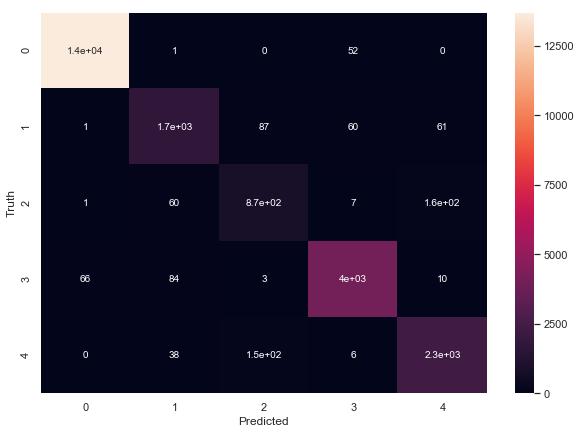

```python
# Creating Heat Map for confusion Matrix

%matplotlib inline
import matplotlib.pyplot as plt
import seaborn as sn
plt.figure(figsize=(10,7))
sn.heatmap(cm, annot=True)
plt.xlabel('Predicted')
plt.ylabel('Truth')
```

The observations from the Classifcation Report are as follows:

**Recall:**

**Understading:**

1. The buckets with equal proportion are good for classification then the buckets with unequal proportion of values.
2. XGB classifier with hyper-parameter optimised parameters can enhance the classification results on correctly feature engineered data.

```python
#==============================================================================
# Effect of K value on classifier
#==============================================================================

# Misclassified_sample = []
# # Calculating error for K values between 1 and 20
# for i in range(1,20):
#     knn = KNeighborsClassifier(n_neighbors=i)
#     knn.fit(X_train_smote, y_train_smote)
#     pred_i = knn.predict(X_test_sltd_feat)
#     Misclassified_sample.append((y_test != pred_i).sum())

# print(Misclassified_sample)
```

[output not shown]

```python
#==============================================================================
# Checking the above data on Random Forest Classifier
#==============================================================================

# from sklearn.ensemble import RandomForestClassifier
model = RandomForestClassifier(n_estimators=20)
model.fit(X_train_smote, y_train_smote)
print("The model score with RFC is: \n")
model.score(X_test_sltd_feat, y_test)
```

```
The model score with RFC is:
```

[output not shown]

The model score for **product_tier** target is **0.9229950621488167**

```python
# Prediction on test data

y_predicted = model.predict(X_test_sltd_feat)
```

```python
# Creating the confusion Matrix

from sklearn.metrics import confusion_matrix
cm = confusion_matrix(y_test, y_predicted)
cm
```

[output not shown]

[figure not shown]

```python
# Creating Heat Map for confusion Matrix

%matplotlib inline
import matplotlib.pyplot as plt
import seaborn as sn
plt.figure(figsize=(10,7))
sn.heatmap(cm, annot=True)
plt.xlabel('Predicted')
plt.ylabel('Truth')
```

#### ==============================================================================

#### **End of Script:**

#### ==============================================================================